# **Group Project 3: Airbnb Data Analytics**

**Group Members:**

- Jesse Shen (23020703)
- Ning Jian (23019851)
- Samantha Quilat (23017224)

### First Part made by: Samantha Quilat (23017224)

### Import Statements

```python
import numpy as np
import pandas as pd
import seaborn as sns
import matplotlib as mpl
import matplotlib.pyplot as plt
import json
import re

from pylab import rcParams
rcParams['figure.figsize'] = 7, 5
rcParams['font.size'] = 10
rcParams['axes.facecolor'] = 'white'
%matplotlib inline

#Data Acquisition
import requests                 #How Python gets the webpages
from bs4 import BeautifulSoup   #Creates structured, searchable object

import os
from tabulate import tabulate
from datetime import datetime, timedelta
import time

!pip install --upgrade selenium
!pip install GeckoDriverManager
!pip install webdriver-manager
from selenium import webdriver #Provides an API for controlling web browsers programmatically.
from selenium import webdriver
from selenium.webdriver.chrome.service import Service
from webdriver_manager.chrome import ChromeDriverManager
from selenium.webdriver.common.by import By
from selenium.common.exceptions import NoSuchElementException
from selenium.webdriver.support.ui import WebDriverWait
from selenium.webdriver.support import expected_conditions as EC

!pip install urllib.parse
from urllib.parse import urlparse, parse_qs

#Methods
from sklearn.metrics.pairwise import cosine_similarity
from sklearn.model_selection import train_test_split
from sklearn.preprocessing import StandardScaler
from sklearn.neighbors import KNeighborsRegressor
```

```
ERROR: Could not find a version that satisfies the requirement GeckoDriverManager (from versions: none)
ERROR: No matching distribution found for GeckoDriverManager
```

```
ERROR: Could not find a version that satisfies the requirement urllib.parse (from versions: none)
ERROR: No matching distribution found for urllib.parse
```

### Web Scraping

```python
#Function to scrape availability and pricing data for a listing
def scrape_listing_pricing(listing_url, guests, num_days):

    #Configure Selenium options
    options = webdriver.ChromeOptions()
    options.add_argument('--headless')  #Run Chrome in headless mode (no GUI)
    options.add_argument('--disable-gpu')  #Disable GPU acceleration
    options.add_argument('--no-sandbox')  #Bypass OS security model
    options.add_argument('--disable-dev-shm-usage')  #Overcome limited resource problems

    #Initialize ChromeDriver
    s=Service(ChromeDriverManager().install())
    driver = webdriver.Chrome(service=s)

    #Open the webpage
    driver.get(listing_url)

    #Get the current URL
    current_url = driver.current_url

    #Parse the URL
    parsed_url = urlparse(current_url)

    #Get the query parameters
    query_params = parse_qs(parsed_url.query)

    #Get the source_impression_id
    source_impression_id = query_params.get('source_impression_id', [None])[0]

    #Create a DataFrame to store the data
    df = pd.DataFrame(columns=['Check-in Date', 'Check-out Date', 'Price in NZD', 'URL'])

    start_date = datetime.now()
    current_date = start_date
    days_scraped = 0

    while days_scraped < num_days:
        checkin_date = current_date.strftime('%Y-%m-%d')
        checkout_date = (current_date + timedelta(days=1)).strftime('%Y-%m-%d')
        url = f"{listing_url}?check_in={checkin_date}&guests={guests}&adults={guests}&check_out={checkout_date}&source_impression_id={source_impression_id}"

        driver.get(url)

        try:
            WebDriverWait(driver, 10).until(EC.presence_of_element_located((By.CLASS_NAME, '_1y74zjx')))
        except Exception as e:
            current_date += timedelta(days=1)
            continue

        soup = BeautifulSoup(driver.page_source, 'html.parser')
        price_element = soup.find(class_='_1y74zjx')

        if price_element:
           price_text = price_element.text.strip()
           price = re.search(r'\d+', price_text).group()
           new_row = pd.DataFrame({
               'Check-in Date': [checkin_date],
               'Check-out Date': [checkout_date],
               'Price in NZD': [price],
               'URL': [url]
           })
           df = pd.concat([df, new_row], ignore_index=True)
           days_scraped += 1

        current_date += timedelta(days=1)

    driver.quit()
    return df
```

```python
def scrape_and_save_data(listing_url, guests, num_days, filename):
    if os.path.exists(filename):
        df = pd.read_csv(filename)
        if len(df) >= num_days:
            return df.head(num_days)
    df = scrape_listing_pricing(listing_url, guests, num_days)
    df.to_csv(filename, index=False)
    return df
```

#### Modern Private · Albany Centre · WiFi · 2 Garage (Hosted by Jim)

```python
listing_url = 'https://www.airbnb.co.nz/rooms/1125096139567330802'
guests = 3
num_days = 90 #3 Months
filename = 'jim_airbnb_data.csv'

#Scrape pricing data for the next 180 days
Jim = scrape_and_save_data(listing_url, guests, num_days, filename)
pd.set_option('display.max_colwidth', 200)
Jim
```

|  | Check-in Date | Check-out Date | Price in NZD | URL |
| --- | --- | --- | --- | --- |
| 0 | 2024-05-24 | 2024-05-25 | 210 | https://www.airbnb.co.nz/rooms/1125096139567330802?check_in=2024-05-24&guests=3&adults=3&check_out=2024-05-25&source_impression_id=p3_1716360138_am4FZZS0vB0cllcB |
| 1 | 2024-06-03 | 2024-06-04 | 177 | https://www.airbnb.co.nz/rooms/1125096139567330802?check_in=2024-06-03&guests=3&adults=3&check_out=2024-06-04&source_impression_id=p3_1716360138_am4FZZS0vB0cllcB |
| 2 | 2024-06-04 | 2024-06-05 | 173 | https://www.airbnb.co.nz/rooms/1125096139567330802?check_in=2024-06-04&guests=3&adults=3&check_out=2024-06-05&source_impression_id=p3_1716360138_am4FZZS0vB0cllcB |
| 3 | 2024-06-05 | 2024-06-06 | 170 | https://www.airbnb.co.nz/rooms/1125096139567330802?check_in=2024-06-05&guests=3&adults=3&check_out=2024-06-06&source_impression_id=p3_1716360138_am4FZZS0vB0cllcB |
| 4 | 2024-06-06 | 2024-06-07 | 170 | https://www.airbnb.co.nz/rooms/1125096139567330802?check_in=2024-06-06&guests=3&adults=3&check_out=2024-06-07&source_impression_id=p3_1716360138_am4FZZS0vB0cllcB |
| ... | ... | ... | ... | ... |
| 85 | 2024-11-25 | 2024-11-26 | 252 | https://www.airbnb.co.nz/rooms/1125096139567330802?check_in=2024-11-25&guests=3&adults=3&check_out=2024-11-26&source_impression_id=p3_1716360138_am4FZZS0vB0cllcB |
| 86 | 2024-11-26 | 2024-11-27 | 253 | https://www.airbnb.co.nz/rooms/1125096139567330802?check_in=2024-11-26&guests=3&adults=3&check_out=2024-11-27&source_impression_id=p3_1716360138_am4FZZS0vB0cllcB |
| 87 | 2024-11-27 | 2024-11-28 | 255 | https://www.airbnb.co.nz/rooms/1125096139567330802?check_in=2024-11-27&guests=3&adults=3&check_out=2024-11-28&source_impression_id=p3_1716360138_am4FZZS0vB0cllcB |
| 88 | 2024-11-28 | 2024-11-29 | 257 | https://www.airbnb.co.nz/rooms/1125096139567330802?check_in=2024-11-28&guests=3&adults=3&check_out=2024-11-29&source_impression_id=p3_1716360138_am4FZZS0vB0cllcB |
| 89 | 2024-11-29 | 2024-11-30 | 276 | https://www.airbnb.co.nz/rooms/1125096139567330802?check_in=2024-11-29&guests=3&adults=3&check_out=2024-11-30&source_impression_id=p3_1716360138_am4FZZS0vB0cllcB |

90 rows × 4 columns

#### Modern Private Home, Full kitchen with 2bathroom (Hosted by Alex)

```python
#Example URL and parameters
listing_url = 'https://www.airbnb.co.nz/rooms/49525122'
guests = 3
num_days = 90 #3 Months
filename = 'alexa_airbnb_data.csv'

#Scrape pricing data for the next 180 days
Alex = scrape_and_save_data(listing_url, guests, num_days, filename)
pd.set_option('display.max_colwidth', 200)
Alex
```

|  | Check-in Date | Check-out Date | Price in NZD | URL |
| --- | --- | --- | --- | --- |
| 0 | 2024-05-24 | 2024-05-25 | 172 | https://www.airbnb.co.nz/rooms/49525122?check_in=2024-05-24&guests=3&adults=3&check_out=2024-05-25&source_impression_id=p3_1716361500_bAclQ5Og9oNC+KqO |
| 1 | 2024-05-25 | 2024-05-26 | 172 | https://www.airbnb.co.nz/rooms/49525122?check_in=2024-05-25&guests=3&adults=3&check_out=2024-05-26&source_impression_id=p3_1716361500_bAclQ5Og9oNC+KqO |
| 2 | 2024-05-26 | 2024-05-27 | 172 | https://www.airbnb.co.nz/rooms/49525122?check_in=2024-05-26&guests=3&adults=3&check_out=2024-05-27&source_impression_id=p3_1716361500_bAclQ5Og9oNC+KqO |
| 3 | 2024-05-27 | 2024-05-28 | 172 | https://www.airbnb.co.nz/rooms/49525122?check_in=2024-05-27&guests=3&adults=3&check_out=2024-05-28&source_impression_id=p3_1716361500_bAclQ5Og9oNC+KqO |
| 4 | 2024-05-28 | 2024-05-29 | 172 | https://www.airbnb.co.nz/rooms/49525122?check_in=2024-05-28&guests=3&adults=3&check_out=2024-05-29&source_impression_id=p3_1716361500_bAclQ5Og9oNC+KqO |
| ... | ... | ... | ... | ... |
| 85 | 2024-10-01 | 2024-10-02 | 218 | https://www.airbnb.co.nz/rooms/49525122?check_in=2024-10-01&guests=3&adults=3&check_out=2024-10-02&source_impression_id=p3_1716361500_bAclQ5Og9oNC+KqO |
| 86 | 2024-10-02 | 2024-10-03 | 218 | https://www.airbnb.co.nz/rooms/49525122?check_in=2024-10-02&guests=3&adults=3&check_out=2024-10-03&source_impression_id=p3_1716361500_bAclQ5Og9oNC+KqO |
| 87 | 2024-10-03 | 2024-10-04 | 218 | https://www.airbnb.co.nz/rooms/49525122?check_in=2024-10-03&guests=3&adults=3&check_out=2024-10-04&source_impression_id=p3_1716361500_bAclQ5Og9oNC+KqO |
| 88 | 2024-10-04 | 2024-10-05 | 218 | https://www.airbnb.co.nz/rooms/49525122?check_in=2024-10-04&guests=3&adults=3&check_out=2024-10-05&source_impression_id=p3_1716361500_bAclQ5Og9oNC+KqO |
| 89 | 2024-10-05 | 2024-10-06 | 218 | https://www.airbnb.co.nz/rooms/49525122?check_in=2024-10-05&guests=3&adults=3&check_out=2024-10-06&source_impression_id=p3_1716361500_bAclQ5Og9oNC+KqO |

90 rows × 4 columns

#### Sleek Urban Oasis In Albany (Hosted by Glenda)

```python
listing_url = 'https://www.airbnb.co.nz/rooms/1044551981539410265'
guests = 3
num_days = 90 #3 Months
filename = 'glenda_airbnb_data.csv'

#Scrape pricing data for the next 180 days
Glenda = scrape_and_save_data(listing_url, guests, num_days, filename)
pd.set_option('display.max_colwidth', 200)
Glenda
```

|  | Check-in Date | Check-out Date | Price in NZD | URL |
| --- | --- | --- | --- | --- |
| 0 | 2024-05-22 | 2024-05-23 | 313 | https://www.airbnb.co.nz/rooms/1044551981539410265?check_in=2024-05-22&guests=3&adults=3&check_out=2024-05-23&source_impression_id=p3_1716362252_GHHtDuwpp0EwNwIK |
| 1 | 2024-05-23 | 2024-05-24 | 313 | https://www.airbnb.co.nz/rooms/1044551981539410265?check_in=2024-05-23&guests=3&adults=3&check_out=2024-05-24&source_impression_id=p3_1716362252_GHHtDuwpp0EwNwIK |
| 2 | 2024-05-25 | 2024-05-26 | 313 | https://www.airbnb.co.nz/rooms/1044551981539410265?check_in=2024-05-25&guests=3&adults=3&check_out=2024-05-26&source_impression_id=p3_1716362252_GHHtDuwpp0EwNwIK |
| 3 | 2024-05-26 | 2024-05-27 | 313 | https://www.airbnb.co.nz/rooms/1044551981539410265?check_in=2024-05-26&guests=3&adults=3&check_out=2024-05-27&source_impression_id=p3_1716362252_GHHtDuwpp0EwNwIK |
| 4 | 2024-05-27 | 2024-05-28 | 313 | https://www.airbnb.co.nz/rooms/1044551981539410265?check_in=2024-05-27&guests=3&adults=3&check_out=2024-05-28&source_impression_id=p3_1716362252_GHHtDuwpp0EwNwIK |
| ... | ... | ... | ... | ... |
| 85 | 2024-09-13 | 2024-09-14 | 313 | https://www.airbnb.co.nz/rooms/1044551981539410265?check_in=2024-09-13&guests=3&adults=3&check_out=2024-09-14&source_impression_id=p3_1716362252_GHHtDuwpp0EwNwIK |
| 86 | 2024-09-14 | 2024-09-15 | 313 | https://www.airbnb.co.nz/rooms/1044551981539410265?check_in=2024-09-14&guests=3&adults=3&check_out=2024-09-15&source_impression_id=p3_1716362252_GHHtDuwpp0EwNwIK |
| 87 | 2024-09-15 | 2024-09-16 | 313 | https://www.airbnb.co.nz/rooms/1044551981539410265?check_in=2024-09-15&guests=3&adults=3&check_out=2024-09-16&source_impression_id=p3_1716362252_GHHtDuwpp0EwNwIK |
| 88 | 2024-09-16 | 2024-09-17 | 313 | https://www.airbnb.co.nz/rooms/1044551981539410265?check_in=2024-09-16&guests=3&adults=3&check_out=2024-09-17&source_impression_id=p3_1716362252_GHHtDuwpp0EwNwIK |
| 89 | 2024-09-17 | 2024-09-18 | 313 | https://www.airbnb.co.nz/rooms/1044551981539410265?check_in=2024-09-17&guests=3&adults=3&check_out=2024-09-18&source_impression_id=p3_1716362252_GHHtDuwpp0EwNwIK |

90 rows × 4 columns

#### Luxury 2 BDR apartment w/ designer interior (Hosted by Joshua)

```python
listing_url = 'https://www.airbnb.co.nz/rooms/566193144075100847'
guests = 3
num_days = 90 #3 Months
filename = 'joshua_airbnb_data.csv'

#Scrape pricing data for the next 180 days
Joshua = scrape_and_save_data(listing_url, guests, num_days, filename)
pd.set_option('display.max_colwidth', 200)
Joshua
```

|  | Check-in Date | Check-out Date | Price in NZD | URL |
| --- | --- | --- | --- | --- |
| 0 | 2024-05-23 | 2024-05-24 | 156 | https://www.airbnb.co.nz/rooms/566193144075100847?check_in=2024-05-23&guests=3&adults=3&check_out=2024-05-24&source_impression_id=p3_1716362788_yutiCjLckrZhwp7u |
| 1 | 2024-05-24 | 2024-05-25 | 188 | https://www.airbnb.co.nz/rooms/566193144075100847?check_in=2024-05-24&guests=3&adults=3&check_out=2024-05-25&source_impression_id=p3_1716362788_yutiCjLckrZhwp7u |
| 2 | 2024-05-25 | 2024-05-26 | 188 | https://www.airbnb.co.nz/rooms/566193144075100847?check_in=2024-05-25&guests=3&adults=3&check_out=2024-05-26&source_impression_id=p3_1716362788_yutiCjLckrZhwp7u |
| 3 | 2024-05-26 | 2024-05-27 | 188 | https://www.airbnb.co.nz/rooms/566193144075100847?check_in=2024-05-26&guests=3&adults=3&check_out=2024-05-27&source_impression_id=p3_1716362788_yutiCjLckrZhwp7u |
| 4 | 2024-05-27 | 2024-05-28 | 235 | https://www.airbnb.co.nz/rooms/566193144075100847?check_in=2024-05-27&guests=3&adults=3&check_out=2024-05-28&source_impression_id=p3_1716362788_yutiCjLckrZhwp7u |
| ... | ... | ... | ... | ... |
| 85 | 2024-08-18 | 2024-08-19 | 410 | https://www.airbnb.co.nz/rooms/566193144075100847?check_in=2024-08-18&guests=3&adults=3&check_out=2024-08-19&source_impression_id=p3_1716362788_yutiCjLckrZhwp7u |
| 86 | 2024-08-19 | 2024-08-20 | 410 | https://www.airbnb.co.nz/rooms/566193144075100847?check_in=2024-08-19&guests=3&adults=3&check_out=2024-08-20&source_impression_id=p3_1716362788_yutiCjLckrZhwp7u |
| 87 | 2024-08-20 | 2024-08-21 | 410 | https://www.airbnb.co.nz/rooms/566193144075100847?check_in=2024-08-20&guests=3&adults=3&check_out=2024-08-21&source_impression_id=p3_1716362788_yutiCjLckrZhwp7u |
| 88 | 2024-08-21 | 2024-08-22 | 410 | https://www.airbnb.co.nz/rooms/566193144075100847?check_in=2024-08-21&guests=3&adults=3&check_out=2024-08-22&source_impression_id=p3_1716362788_yutiCjLckrZhwp7u |
| 89 | 2024-08-22 | 2024-08-23 | 410 | https://www.airbnb.co.nz/rooms/566193144075100847?check_in=2024-08-22&guests=3&adults=3&check_out=2024-08-23&source_impression_id=p3_1716362788_yutiCjLckrZhwp7u |

90 rows × 4 columns

#### 7 mins drive to Albany Centre, Private & elegant (Hosted by Prince)

```python
listing_url = 'https://www.airbnb.co.nz/rooms/1115473858923244250'
guests = 3
num_days = 90 #3 Months
filename = 'prince_airbnb_data.csv'

#Scrape pricing data for the next 180 days
Prince = scrape_and_save_data(listing_url, guests, num_days, filename)
pd.set_option('display.max_colwidth', 200)
Prince
```

|  | Check-in Date | Check-out Date | Price in NZD | URL |
| --- | --- | --- | --- | --- |
| 0 | 2024-05-22 | 2024-05-23 | 210 | https://www.airbnb.co.nz/rooms/1115473858923244250?check_in=2024-05-22&guests=3&adults=3&check_out=2024-05-23&source_impression_id=p3_1716369803_UkzPMdTCxSJ6iuH3 |
| 1 | 2024-05-23 | 2024-05-24 | 210 | https://www.airbnb.co.nz/rooms/1115473858923244250?check_in=2024-05-23&guests=3&adults=3&check_out=2024-05-24&source_impression_id=p3_1716369803_UkzPMdTCxSJ6iuH3 |
| 2 | 2024-05-27 | 2024-05-28 | 210 | https://www.airbnb.co.nz/rooms/1115473858923244250?check_in=2024-05-27&guests=3&adults=3&check_out=2024-05-28&source_impression_id=p3_1716369803_UkzPMdTCxSJ6iuH3 |
| 3 | 2024-05-28 | 2024-05-29 | 210 | https://www.airbnb.co.nz/rooms/1115473858923244250?check_in=2024-05-28&guests=3&adults=3&check_out=2024-05-29&source_impression_id=p3_1716369803_UkzPMdTCxSJ6iuH3 |
| 4 | 2024-05-29 | 2024-05-30 | 210 | https://www.airbnb.co.nz/rooms/1115473858923244250?check_in=2024-05-29&guests=3&adults=3&check_out=2024-05-30&source_impression_id=p3_1716369803_UkzPMdTCxSJ6iuH3 |
| ... | ... | ... | ... | ... |
| 85 | 2024-08-20 | 2024-08-21 | 235 | https://www.airbnb.co.nz/rooms/1115473858923244250?check_in=2024-08-20&guests=3&adults=3&check_out=2024-08-21&source_impression_id=p3_1716369803_UkzPMdTCxSJ6iuH3 |
| 86 | 2024-08-21 | 2024-08-22 | 235 | https://www.airbnb.co.nz/rooms/1115473858923244250?check_in=2024-08-21&guests=3&adults=3&check_out=2024-08-22&source_impression_id=p3_1716369803_UkzPMdTCxSJ6iuH3 |
| 87 | 2024-08-22 | 2024-08-23 | 235 | https://www.airbnb.co.nz/rooms/1115473858923244250?check_in=2024-08-22&guests=3&adults=3&check_out=2024-08-23&source_impression_id=p3_1716369803_UkzPMdTCxSJ6iuH3 |
| 88 | 2024-08-23 | 2024-08-24 | 235 | https://www.airbnb.co.nz/rooms/1115473858923244250?check_in=2024-08-23&guests=3&adults=3&check_out=2024-08-24&source_impression_id=p3_1716369803_UkzPMdTCxSJ6iuH3 |
| 89 | 2024-08-24 | 2024-08-25 | 235 | https://www.airbnb.co.nz/rooms/1115473858923244250?check_in=2024-08-24&guests=3&adults=3&check_out=2024-08-25&source_impression_id=p3_1716369803_UkzPMdTCxSJ6iuH3 |

90 rows × 4 columns

#### Pinehill 2 Bedroom Unit (Hosted by Tiffany)

```python
listing_url = 'https://www.airbnb.co.nz/rooms/1017748763616316098'
guests = 3
num_days = 90 #3 Months
filename = 'tiffany_airbnb_data.csv'

#Scrape pricing data for the next 180 days
Tiffany = scrape_and_save_data(listing_url, guests, num_days, filename)
pd.set_option('display.max_colwidth', 200)
Tiffany
```

|  | Check-in Date | Check-out Date | Price in NZD | URL |
| --- | --- | --- | --- | --- |
| 0 | 2024-05-31 | 2024-06-01 | 236 | https://www.airbnb.co.nz/rooms/1017748763616316098?check_in=2024-05-31&guests=3&adults=3&check_out=2024-06-01&source_impression_id=p3_1716370038_pqdFThnXtIHe9zJt |
| 1 | 2024-06-01 | 2024-06-02 | 258 | https://www.airbnb.co.nz/rooms/1017748763616316098?check_in=2024-06-01&guests=3&adults=3&check_out=2024-06-02&source_impression_id=p3_1716370038_pqdFThnXtIHe9zJt |
| 2 | 2024-06-02 | 2024-06-03 | 258 | https://www.airbnb.co.nz/rooms/1017748763616316098?check_in=2024-06-02&guests=3&adults=3&check_out=2024-06-03&source_impression_id=p3_1716370038_pqdFThnXtIHe9zJt |
| 3 | 2024-06-03 | 2024-06-04 | 258 | https://www.airbnb.co.nz/rooms/1017748763616316098?check_in=2024-06-03&guests=3&adults=3&check_out=2024-06-04&source_impression_id=p3_1716370038_pqdFThnXtIHe9zJt |
| 4 | 2024-06-04 | 2024-06-05 | 258 | https://www.airbnb.co.nz/rooms/1017748763616316098?check_in=2024-06-04&guests=3&adults=3&check_out=2024-06-05&source_impression_id=p3_1716370038_pqdFThnXtIHe9zJt |
| ... | ... | ... | ... | ... |
| 85 | 2024-09-08 | 2024-09-09 | 262 | https://www.airbnb.co.nz/rooms/1017748763616316098?check_in=2024-09-08&guests=3&adults=3&check_out=2024-09-09&source_impression_id=p3_1716370038_pqdFThnXtIHe9zJt |
| 86 | 2024-09-09 | 2024-09-10 | 262 | https://www.airbnb.co.nz/rooms/1017748763616316098?check_in=2024-09-09&guests=3&adults=3&check_out=2024-09-10&source_impression_id=p3_1716370038_pqdFThnXtIHe9zJt |
| 87 | 2024-09-10 | 2024-09-11 | 262 | https://www.airbnb.co.nz/rooms/1017748763616316098?check_in=2024-09-10&guests=3&adults=3&check_out=2024-09-11&source_impression_id=p3_1716370038_pqdFThnXtIHe9zJt |
| 88 | 2024-09-11 | 2024-09-12 | 262 | https://www.airbnb.co.nz/rooms/1017748763616316098?check_in=2024-09-11&guests=3&adults=3&check_out=2024-09-12&source_impression_id=p3_1716370038_pqdFThnXtIHe9zJt |
| 89 | 2024-09-12 | 2024-09-13 | 262 | https://www.airbnb.co.nz/rooms/1017748763616316098?check_in=2024-09-12&guests=3&adults=3&check_out=2024-09-13&source_impression_id=p3_1716370038_pqdFThnXtIHe9zJt |

90 rows × 4 columns

#### Luxury brand new house with free parking (Hosted by Michael)

```python
listing_url = 'https://www.airbnb.co.nz/rooms/1008128615688965304'
guests = 3
num_days = 90 #3 Months
filename = 'michael_airbnb_data.csv'

#Scrape pricing data for the next 180 days
Michael = scrape_and_save_data(listing_url, guests, num_days, filename)
pd.set_option('display.max_colwidth', 200)
Michael
```

|  | Check-in Date | Check-out Date | Price in NZD | URL |
| --- | --- | --- | --- | --- |
| 0 | 2024-05-27 | 2024-05-28 | 141 | https://www.airbnb.co.nz/rooms/1008128615688965304?check_in=2024-05-27&guests=3&adults=3&check_out=2024-05-28&source_impression_id=p3_1716370492_ruvZ+Rd7L31+3RPB |
| 1 | 2024-05-28 | 2024-05-29 | 141 | https://www.airbnb.co.nz/rooms/1008128615688965304?check_in=2024-05-28&guests=3&adults=3&check_out=2024-05-29&source_impression_id=p3_1716370492_ruvZ+Rd7L31+3RPB |
| 2 | 2024-05-29 | 2024-05-30 | 141 | https://www.airbnb.co.nz/rooms/1008128615688965304?check_in=2024-05-29&guests=3&adults=3&check_out=2024-05-30&source_impression_id=p3_1716370492_ruvZ+Rd7L31+3RPB |
| 3 | 2024-05-30 | 2024-05-31 | 141 | https://www.airbnb.co.nz/rooms/1008128615688965304?check_in=2024-05-30&guests=3&adults=3&check_out=2024-05-31&source_impression_id=p3_1716370492_ruvZ+Rd7L31+3RPB |
| 4 | 2024-06-03 | 2024-06-04 | 178 | https://www.airbnb.co.nz/rooms/1008128615688965304?check_in=2024-06-03&guests=3&adults=3&check_out=2024-06-04&source_impression_id=p3_1716370492_ruvZ+Rd7L31+3RPB |
| ... | ... | ... | ... | ... |
| 85 | 2024-10-02 | 2024-10-03 | 271 | https://www.airbnb.co.nz/rooms/1008128615688965304?check_in=2024-10-02&guests=3&adults=3&check_out=2024-10-03&source_impression_id=p3_1716370492_ruvZ+Rd7L31+3RPB |
| 86 | 2024-10-03 | 2024-10-04 | 271 | https://www.airbnb.co.nz/rooms/1008128615688965304?check_in=2024-10-03&guests=3&adults=3&check_out=2024-10-04&source_impression_id=p3_1716370492_ruvZ+Rd7L31+3RPB |
| 87 | 2024-10-04 | 2024-10-05 | 271 | https://www.airbnb.co.nz/rooms/1008128615688965304?check_in=2024-10-04&guests=3&adults=3&check_out=2024-10-05&source_impression_id=p3_1716370492_ruvZ+Rd7L31+3RPB |
| 88 | 2024-10-05 | 2024-10-06 | 271 | https://www.airbnb.co.nz/rooms/1008128615688965304?check_in=2024-10-05&guests=3&adults=3&check_out=2024-10-06&source_impression_id=p3_1716370492_ruvZ+Rd7L31+3RPB |
| 89 | 2024-10-06 | 2024-10-07 | 271 | https://www.airbnb.co.nz/rooms/1008128615688965304?check_in=2024-10-06&guests=3&adults=3&check_out=2024-10-07&source_impression_id=p3_1716370492_ruvZ+Rd7L31+3RPB |

90 rows × 4 columns

#### Delightful Double Bedroom Unit (Hosted by Noorani)

```python
listing_url = 'https://www.airbnb.co.nz/rooms/698990872569498801'
guests = 3
num_days = 90 #3 Months
filename = 'noorani_airbnb_data.csv'

#Scrape pricing data for the next 180 days
Noorani = scrape_and_save_data(listing_url, guests, num_days, filename)
pd.set_option('display.max_colwidth', 200)
Noorani
```

|  | Check-in Date | Check-out Date | Price in NZD | URL |
| --- | --- | --- | --- | --- |
| 0 | 2024-05-22 | 2024-05-23 | 133 | https://www.airbnb.co.nz/rooms/698990872569498801?check_in=2024-05-22&guests=3&adults=3&check_out=2024-05-23&source_impression_id=p3_1716374452_Wv/Z9EAbGc0vtfJu |
| 1 | 2024-05-23 | 2024-05-24 | 133 | https://www.airbnb.co.nz/rooms/698990872569498801?check_in=2024-05-23&guests=3&adults=3&check_out=2024-05-24&source_impression_id=p3_1716374452_Wv/Z9EAbGc0vtfJu |
| 2 | 2024-05-24 | 2024-05-25 | 133 | https://www.airbnb.co.nz/rooms/698990872569498801?check_in=2024-05-24&guests=3&adults=3&check_out=2024-05-25&source_impression_id=p3_1716374452_Wv/Z9EAbGc0vtfJu |
| 3 | 2024-05-30 | 2024-05-31 | 139 | https://www.airbnb.co.nz/rooms/698990872569498801?check_in=2024-05-30&guests=3&adults=3&check_out=2024-05-31&source_impression_id=p3_1716374452_Wv/Z9EAbGc0vtfJu |
| 4 | 2024-05-31 | 2024-06-01 | 150 | https://www.airbnb.co.nz/rooms/698990872569498801?check_in=2024-05-31&guests=3&adults=3&check_out=2024-06-01&source_impression_id=p3_1716374452_Wv/Z9EAbGc0vtfJu |
| ... | ... | ... | ... | ... |
| 85 | 2024-08-22 | 2024-08-23 | 197 | https://www.airbnb.co.nz/rooms/698990872569498801?check_in=2024-08-22&guests=3&adults=3&check_out=2024-08-23&source_impression_id=p3_1716374452_Wv/Z9EAbGc0vtfJu |
| 86 | 2024-08-23 | 2024-08-24 | 201 | https://www.airbnb.co.nz/rooms/698990872569498801?check_in=2024-08-23&guests=3&adults=3&check_out=2024-08-24&source_impression_id=p3_1716374452_Wv/Z9EAbGc0vtfJu |
| 87 | 2024-08-24 | 2024-08-25 | 197 | https://www.airbnb.co.nz/rooms/698990872569498801?check_in=2024-08-24&guests=3&adults=3&check_out=2024-08-25&source_impression_id=p3_1716374452_Wv/Z9EAbGc0vtfJu |
| 88 | 2024-08-25 | 2024-08-26 | 197 | https://www.airbnb.co.nz/rooms/698990872569498801?check_in=2024-08-25&guests=3&adults=3&check_out=2024-08-26&source_impression_id=p3_1716374452_Wv/Z9EAbGc0vtfJu |
| 89 | 2024-08-26 | 2024-08-27 | 197 | https://www.airbnb.co.nz/rooms/698990872569498801?check_in=2024-08-26&guests=3&adults=3&check_out=2024-08-27&source_impression_id=p3_1716374452_Wv/Z9EAbGc0vtfJu |

90 rows × 4 columns

#### Top Schoolzone+Top Golf+Top Location - By the Bay! (Hosted by Andy)

```python
listing_url = 'https://www.airbnb.co.nz/rooms/1141075033936083504'
guests = 3
num_days = 90 #3 Months
filename = 'andy_airbnb_data.csv'

#Scrape pricing data for the next 180 days
Andy = scrape_and_save_data(listing_url, guests, num_days, filename)
pd.set_option('display.max_colwidth', 200)
Andy
```

|  | Check-in Date | Check-out Date | Price in NZD | URL |
| --- | --- | --- | --- | --- |
| 0 | 2024-05-22 | 2024-05-23 | 193 | https://www.airbnb.co.nz/rooms/1141075033936083504?check_in=2024-05-22&guests=3&adults=3&check_out=2024-05-23&source_impression_id=p3_1716375187_DzCQ/fil4FkTfY2q |
| 1 | 2024-05-26 | 2024-05-27 | 193 | https://www.airbnb.co.nz/rooms/1141075033936083504?check_in=2024-05-26&guests=3&adults=3&check_out=2024-05-27&source_impression_id=p3_1716375187_DzCQ/fil4FkTfY2q |
| 2 | 2024-05-27 | 2024-05-28 | 193 | https://www.airbnb.co.nz/rooms/1141075033936083504?check_in=2024-05-27&guests=3&adults=3&check_out=2024-05-28&source_impression_id=p3_1716375187_DzCQ/fil4FkTfY2q |
| 3 | 2024-05-28 | 2024-05-29 | 193 | https://www.airbnb.co.nz/rooms/1141075033936083504?check_in=2024-05-28&guests=3&adults=3&check_out=2024-05-29&source_impression_id=p3_1716375187_DzCQ/fil4FkTfY2q |
| 4 | 2024-05-29 | 2024-05-30 | 193 | https://www.airbnb.co.nz/rooms/1141075033936083504?check_in=2024-05-29&guests=3&adults=3&check_out=2024-05-30&source_impression_id=p3_1716375187_DzCQ/fil4FkTfY2q |
| ... | ... | ... | ... | ... |
| 85 | 2024-10-01 | 2024-10-02 | 245 | https://www.airbnb.co.nz/rooms/1141075033936083504?check_in=2024-10-01&guests=3&adults=3&check_out=2024-10-02&source_impression_id=p3_1716375187_DzCQ/fil4FkTfY2q |
| 86 | 2024-10-02 | 2024-10-03 | 245 | https://www.airbnb.co.nz/rooms/1141075033936083504?check_in=2024-10-02&guests=3&adults=3&check_out=2024-10-03&source_impression_id=p3_1716375187_DzCQ/fil4FkTfY2q |
| 87 | 2024-10-03 | 2024-10-04 | 245 | https://www.airbnb.co.nz/rooms/1141075033936083504?check_in=2024-10-03&guests=3&adults=3&check_out=2024-10-04&source_impression_id=p3_1716375187_DzCQ/fil4FkTfY2q |
| 88 | 2024-10-06 | 2024-10-07 | 245 | https://www.airbnb.co.nz/rooms/1141075033936083504?check_in=2024-10-06&guests=3&adults=3&check_out=2024-10-07&source_impression_id=p3_1716375187_DzCQ/fil4FkTfY2q |
| 89 | 2024-10-07 | 2024-10-08 | 245 | https://www.airbnb.co.nz/rooms/1141075033936083504?check_in=2024-10-07&guests=3&adults=3&check_out=2024-10-08&source_impression_id=p3_1716375187_DzCQ/fil4FkTfY2q |

90 rows × 4 columns

#### Harbour View Guesthouse (Hosted by Donghong)

```python
listing_url = 'https://www.airbnb.co.nz/rooms/31574846'
guests = 3
num_days = 90 #3 Months
filename = 'donghong_airbnb_data.csv'

#Scrape pricing data for the next 180 days
Donghong = scrape_and_save_data(listing_url, guests, num_days, filename)
pd.set_option('display.max_colwidth', 200)
Donghong
```

|  | Check-in Date | Check-out Date | Price in NZD | URL |
| --- | --- | --- | --- | --- |
| 0 | 2024-05-23 | 2024-05-24 | 199 | https://www.airbnb.co.nz/rooms/31574846?check_in=2024-05-23&guests=3&adults=3&check_out=2024-05-24&source_impression_id=p3_1716375950_nyvNahiRAFq7eyNG |
| 1 | 2024-05-24 | 2024-05-25 | 199 | https://www.airbnb.co.nz/rooms/31574846?check_in=2024-05-24&guests=3&adults=3&check_out=2024-05-25&source_impression_id=p3_1716375950_nyvNahiRAFq7eyNG |
| 2 | 2024-05-25 | 2024-05-26 | 199 | https://www.airbnb.co.nz/rooms/31574846?check_in=2024-05-25&guests=3&adults=3&check_out=2024-05-26&source_impression_id=p3_1716375950_nyvNahiRAFq7eyNG |
| 3 | 2024-05-26 | 2024-05-27 | 199 | https://www.airbnb.co.nz/rooms/31574846?check_in=2024-05-26&guests=3&adults=3&check_out=2024-05-27&source_impression_id=p3_1716375950_nyvNahiRAFq7eyNG |
| 4 | 2024-05-27 | 2024-05-28 | 199 | https://www.airbnb.co.nz/rooms/31574846?check_in=2024-05-27&guests=3&adults=3&check_out=2024-05-28&source_impression_id=p3_1716375950_nyvNahiRAFq7eyNG |
| ... | ... | ... | ... | ... |
| 85 | 2024-08-16 | 2024-08-17 | 199 | https://www.airbnb.co.nz/rooms/31574846?check_in=2024-08-16&guests=3&adults=3&check_out=2024-08-17&source_impression_id=p3_1716375950_nyvNahiRAFq7eyNG |
| 86 | 2024-08-17 | 2024-08-18 | 199 | https://www.airbnb.co.nz/rooms/31574846?check_in=2024-08-17&guests=3&adults=3&check_out=2024-08-18&source_impression_id=p3_1716375950_nyvNahiRAFq7eyNG |
| 87 | 2024-08-18 | 2024-08-19 | 199 | https://www.airbnb.co.nz/rooms/31574846?check_in=2024-08-18&guests=3&adults=3&check_out=2024-08-19&source_impression_id=p3_1716375950_nyvNahiRAFq7eyNG |
| 88 | 2024-08-19 | 2024-08-20 | 199 | https://www.airbnb.co.nz/rooms/31574846?check_in=2024-08-19&guests=3&adults=3&check_out=2024-08-20&source_impression_id=p3_1716375950_nyvNahiRAFq7eyNG |
| 89 | 2024-08-20 | 2024-08-21 | 199 | https://www.airbnb.co.nz/rooms/31574846?check_in=2024-08-20&guests=3&adults=3&check_out=2024-08-21&source_impression_id=p3_1716375950_nyvNahiRAFq7eyNG |

90 rows × 4 columns

### Methods

#### Merging AirBnB Data

```python
Jim.columns = ['Jim Check-in Date', 'Jim Check-out Date', 'Jim Price in NZD', 'URL']
Alex.columns = ['Alex Check-in Date', 'Alex Check-out Date', 'Alex Price in NZD', 'URL']
Glenda.columns = ['Glenda Check-in Date', 'Glenda Check-out Date', 'Glenda Price in NZD', 'URL']
Joshua.columns = ['Joshua Check-in Date', 'Joshua Check-out Date', 'Joshua Price in NZD', 'URL']
Prince.columns = ['Prince Check-in Date', 'Prince Check-out Date', 'Prince Price in NZD', 'URL']
Tiffany.columns = ['Tiffany Check-in Date', 'Tiffany Check-out Date', 'Tiffany Price in NZD', 'URL']
Michael.columns = ['Michael Check-in Date', 'Michael Check-out Date', 'Michael Price in NZD', 'URL']
Noorani.columns = ['Noorani Check-in Date', 'Noorani Check-out Date', 'Noorani Price in NZD', 'URL']
Andy.columns = ['Andy Check-in Date', 'Andy Check-out Date', 'Andy Price in NZD', 'URL']
Donghong.columns = ['Donghong Check-in Date', 'Donghong Check-out Date', 'Donghong Price in NZD', 'URL']

Airbnb = pd.concat([Jim, Alex, Glenda, Joshua, Prince, Tiffany, Michael, Noorani, Andy, Donghong], axis=1)

Airbnb = Airbnb.drop(columns=[col for col in Airbnb.columns if 'URL' in col]) #Drops URL column

names = sorted(set(col.split()[0] for col in Airbnb.columns))

#Adjust column names to match the desired format
new_columns = []
for name in names:
    new_columns.extend([f"{name} Check-in Date", f"{name} Check-out Date", f"{name} Price in NZD"])

#Reorder the columns
Airbnb = Airbnb[new_columns]

#Fill NaN values with 0
AirbnbData = Airbnb.fillna(0)
AirbnbData
```

|  | Alex Check-in Date | Alex Check-out Date | Alex Price in NZD | Andy Check-in Date | Andy Check-out Date | Andy Price in NZD | Donghong Check-in Date | Donghong Check-out Date | Donghong Price in NZD | Glenda Check-in Date | ... | Michael Price in NZD | Noorani Check-in Date | Noorani Check-out Date | Noorani Price in NZD | Prince Check-in Date | Prince Check-out Date | Prince Price in NZD | Tiffany Check-in Date | Tiffany Check-out Date | Tiffany Price in NZD |
| --- | --- | --- | --- | --- | --- | --- | --- | --- | --- | --- | --- | --- | --- | --- | --- | --- | --- | --- | --- | --- | --- |
| 0 | 2024-05-24 | 2024-05-25 | 172 | 2024-05-22 | 2024-05-23 | 193 | 2024-05-23 | 2024-05-24 | 199 | 2024-05-22 | ... | 141 | 2024-05-22 | 2024-05-23 | 133 | 2024-05-22 | 2024-05-23 | 210 | 2024-05-31 | 2024-06-01 | 236 |
| 1 | 2024-05-25 | 2024-05-26 | 172 | 2024-05-26 | 2024-05-27 | 193 | 2024-05-24 | 2024-05-25 | 199 | 2024-05-23 | ... | 141 | 2024-05-23 | 2024-05-24 | 133 | 2024-05-23 | 2024-05-24 | 210 | 2024-06-01 | 2024-06-02 | 258 |
| 2 | 2024-05-26 | 2024-05-27 | 172 | 2024-05-27 | 2024-05-28 | 193 | 2024-05-25 | 2024-05-26 | 199 | 2024-05-25 | ... | 141 | 2024-05-24 | 2024-05-25 | 133 | 2024-05-27 | 2024-05-28 | 210 | 2024-06-02 | 2024-06-03 | 258 |
| 3 | 2024-05-27 | 2024-05-28 | 172 | 2024-05-28 | 2024-05-29 | 193 | 2024-05-26 | 2024-05-27 | 199 | 2024-05-26 | ... | 141 | 2024-05-30 | 2024-05-31 | 139 | 2024-05-28 | 2024-05-29 | 210 | 2024-06-03 | 2024-06-04 | 258 |
| 4 | 2024-05-28 | 2024-05-29 | 172 | 2024-05-29 | 2024-05-30 | 193 | 2024-05-27 | 2024-05-28 | 199 | 2024-05-27 | ... | 178 | 2024-05-31 | 2024-06-01 | 150 | 2024-05-29 | 2024-05-30 | 210 | 2024-06-04 | 2024-06-05 | 258 |
| ... | ... | ... | ... | ... | ... | ... | ... | ... | ... | ... | ... | ... | ... | ... | ... | ... | ... | ... | ... | ... | ... |
| 85 | 2024-10-01 | 2024-10-02 | 218 | 2024-10-01 | 2024-10-02 | 245 | 2024-08-16 | 2024-08-17 | 199 | 2024-09-13 | ... | 271 | 2024-08-22 | 2024-08-23 | 197 | 2024-08-20 | 2024-08-21 | 235 | 2024-09-08 | 2024-09-09 | 262 |
| 86 | 2024-10-02 | 2024-10-03 | 218 | 2024-10-02 | 2024-10-03 | 245 | 2024-08-17 | 2024-08-18 | 199 | 2024-09-14 | ... | 271 | 2024-08-23 | 2024-08-24 | 201 | 2024-08-21 | 2024-08-22 | 235 | 2024-09-09 | 2024-09-10 | 262 |
| 87 | 2024-10-03 | 2024-10-04 | 218 | 2024-10-03 | 2024-10-04 | 245 | 2024-08-18 | 2024-08-19 | 199 | 2024-09-15 | ... | 271 | 2024-08-24 | 2024-08-25 | 197 | 2024-08-22 | 2024-08-23 | 235 | 2024-09-10 | 2024-09-11 | 262 |
| 88 | 2024-10-04 | 2024-10-05 | 218 | 2024-10-06 | 2024-10-07 | 245 | 2024-08-19 | 2024-08-20 | 199 | 2024-09-16 | ... | 271 | 2024-08-25 | 2024-08-26 | 197 | 2024-08-23 | 2024-08-24 | 235 | 2024-09-11 | 2024-09-12 | 262 |
| 89 | 2024-10-05 | 2024-10-06 | 218 | 2024-10-07 | 2024-10-08 | 245 | 2024-08-20 | 2024-08-21 | 199 | 2024-09-17 | ... | 271 | 2024-08-26 | 2024-08-27 | 197 | 2024-08-24 | 2024-08-25 | 235 | 2024-09-12 | 2024-09-13 | 262 |

90 rows × 30 columns

#### Scatter Plots

##### Jim & Alex

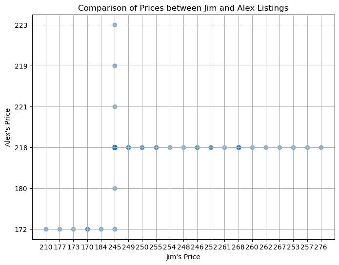

```python
x_column = 'Jim Price in NZD'
y_column = 'Alex Price in NZD'

AirbnbData[x_column] = AirbnbData[x_column].astype(str)
AirbnbData[y_column] = AirbnbData[y_column].astype(str)

plt.figure(figsize=(8, 6))
plt.scatter(AirbnbData[x_column], AirbnbData[y_column], alpha=0.5)
plt.title(f'Comparison of Prices between Jim and Alex Listings')
plt.xlabel("Jim's Price")
plt.ylabel("Alex's Price")
plt.grid(True)
plt.show()
```

##### Jim & Glenda

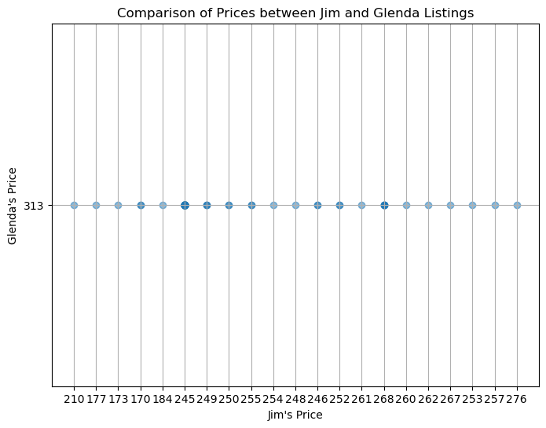

```python
x_column = 'Jim Price in NZD'
y_column = 'Glenda Price in NZD'

AirbnbData[x_column] = AirbnbData[x_column].astype(str)
AirbnbData[y_column] = AirbnbData[y_column].astype(str)

plt.figure(figsize=(8, 6))
plt.scatter(AirbnbData[x_column], AirbnbData[y_column], alpha=0.5)
plt.title(f'Comparison of Prices between Jim and Glenda Listings')
plt.xlabel("Jim's Price")
plt.ylabel("Glenda's Price")
plt.grid(True)
plt.show()
```

##### Jim & Joshua

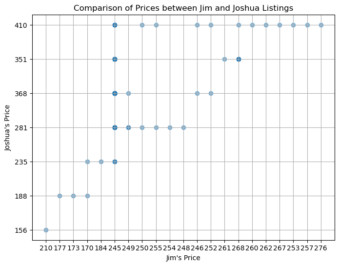

```python
x_column = 'Jim Price in NZD'
y_column = 'Joshua Price in NZD'

AirbnbData[x_column] = AirbnbData[x_column].astype(str)
AirbnbData[y_column] = AirbnbData[y_column].astype(str)

plt.figure(figsize=(8, 6))
plt.scatter(AirbnbData[x_column], AirbnbData[y_column], alpha=0.5)
plt.title(f'Comparison of Prices between Jim and Joshua Listings')
plt.xlabel("Jim's Price")
plt.ylabel("Joshua's Price")
plt.grid(True)
plt.show()
```

##### Jim & Prince

[figure not shown]

```python
x_column = 'Jim Price in NZD'
y_column = 'Prince Price in NZD'

AirbnbData[x_column] = AirbnbData[x_column].astype(str)
AirbnbData[y_column] = AirbnbData[y_column].astype(str)

plt.figure(figsize=(8, 6))
plt.scatter(AirbnbData[x_column], AirbnbData[y_column], alpha=0.5)
plt.title(f'Comparison of Prices between Jim and Lucy Listings')
plt.xlabel("Jim's Price")
plt.ylabel("Prince's Price")
plt.grid(True)
plt.show()
```

##### Jim & Tiffany

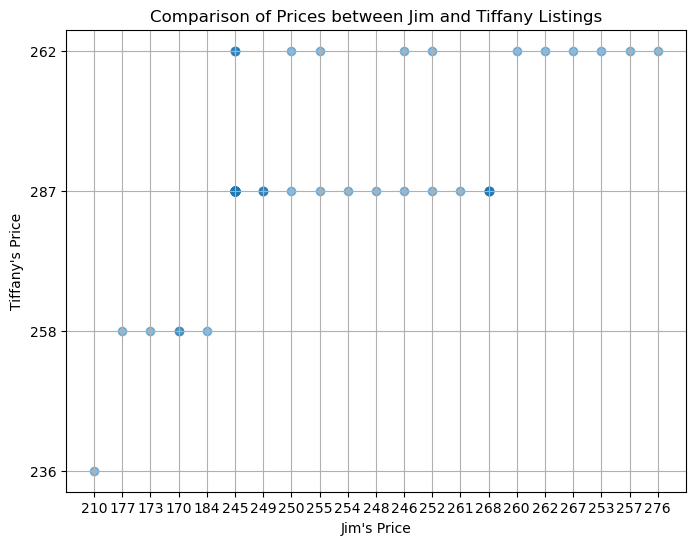

```python
x_column = 'Jim Price in NZD'
y_column = 'Tiffany Price in NZD'

AirbnbData[x_column] = AirbnbData[x_column].astype(str)
AirbnbData[y_column] = AirbnbData[y_column].astype(str)

plt.figure(figsize=(8, 6))
plt.scatter(AirbnbData[x_column], AirbnbData[y_column], alpha=0.5)
plt.title(f'Comparison of Prices between Jim and Tiffany Listings')
plt.xlabel("Jim's Price")
plt.ylabel("Tiffany's Price")
plt.grid(True)
plt.show()
```

##### Jim & Michael

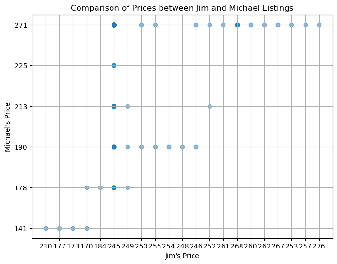

```python
x_column = 'Jim Price in NZD'
y_column = 'Michael Price in NZD'

AirbnbData[x_column] = AirbnbData[x_column].astype(str)
AirbnbData[y_column] = AirbnbData[y_column].astype(str)

plt.figure(figsize=(8, 6))
plt.scatter(AirbnbData[x_column], AirbnbData[y_column], alpha=0.5)
plt.title(f'Comparison of Prices between Jim and Michael Listings')
plt.xlabel("Jim's Price")
plt.ylabel("Michael's Price")
plt.grid(True)
plt.show()
```

##### Jim & Noorani

[figure not shown]

```python
x_column = 'Jim Price in NZD'
y_column = 'Noorani Price in NZD'

AirbnbData[x_column] = AirbnbData[x_column].astype(str)
AirbnbData[y_column] = AirbnbData[y_column].astype(str)

plt.figure(figsize=(8, 6))
plt.scatter(AirbnbData[x_column], AirbnbData[y_column], alpha=0.5)
plt.title(f'Comparison of Prices between Jim and Angela Listings')
plt.xlabel("Jim's Price")
plt.ylabel("Noorani's Price")
plt.grid(True)
plt.show()
```

##### Jim & Andy

[figure not shown]

```python
x_column = 'Jim Price in NZD'
y_column = 'Andy Price in NZD'

AirbnbData[x_column] = AirbnbData[x_column].astype(str)
AirbnbData[y_column] = AirbnbData[y_column].astype(str)

plt.figure(figsize=(8, 6))
plt.scatter(AirbnbData[x_column], AirbnbData[y_column], alpha=0.5)
plt.title(f'Comparison of Prices between Jim and Alpha Listings')
plt.xlabel("Jim's Price")
plt.ylabel("Andy's Price")
plt.grid(True)
plt.show()
```

##### Jim & Donghong

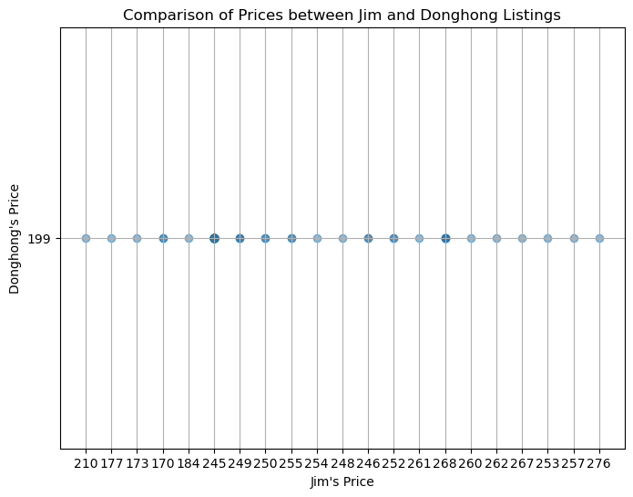

```python
x_column = 'Jim Price in NZD'
y_column = 'Donghong Price in NZD'

AirbnbData[x_column] = AirbnbData[x_column].astype(str)
AirbnbData[y_column] = AirbnbData[y_column].astype(str)

plt.figure(figsize=(8, 6))
plt.scatter(AirbnbData[x_column], AirbnbData[y_column], alpha=0.5)
plt.title(f'Comparison of Prices between Jim and Donghong Listings')
plt.xlabel("Jim's Price")
plt.ylabel("Donghong's Price")
plt.grid(True)
plt.show()
```

#### Cosine Similarity

```python
def cosine_similarity(x, y):
    # Convert input arrays to numeric values
    x = np.array(x, dtype=float)
    y = np.array(y, dtype=float)

    dot_prod = np.dot(x, y)
    x_len = np.linalg.norm(x)
    y_len = np.linalg.norm(y)

    if x_len == 0 or y_len == 0:
        return 0

    similarity = dot_prod / (x_len * y_len)
    return similarity

# Extract the price columns for saimilarity calculation
price_columns = [col for col in AirbnbData.columns if 'Price in NZD' in col]

# DataFrame with only the price columns
price_df = AirbnbData[price_columns]

# Calculate cosine similarity for each pair of listings
num_listings = len(price_columns)
similarity_matrix = np.zeros((num_listings, num_listings))

for i in range(num_listings):
    for j in range(num_listings):
        similarity_matrix[i, j] = cosine_similarity(price_df.iloc[:, i], price_df.iloc[:, j])

# Convert the similarity matrix into a DataFrame for better readability
similarity_df = pd.DataFrame(similarity_matrix, index=price_columns, columns=price_columns)

similarity_df
```

|  | Alex Price in NZD | Andy Price in NZD | Donghong Price in NZD | Glenda Price in NZD | Jim Price in NZD | Joshua Price in NZD | Michael Price in NZD | Noorani Price in NZD | Prince Price in NZD | Tiffany Price in NZD |
| --- | --- | --- | --- | --- | --- | --- | --- | --- | --- | --- |
| Alex Price in NZD | 1.000000 | 0.995236 | 0.998196 | 0.998196 | 0.998970 | 0.990556 | 0.988205 | 0.993731 | 0.998880 | 0.998647 |
| Andy Price in NZD | 0.995236 | 1.000000 | 0.995846 | 0.995846 | 0.996101 | 0.991528 | 0.991827 | 0.995112 | 0.996860 | 0.994432 |
| Donghong Price in NZD | 0.998196 | 0.995846 | 1.000000 | 1.000000 | 0.997077 | 0.985059 | 0.983965 | 0.991315 | 0.999057 | 0.999164 |
| Glenda Price in NZD | 0.998196 | 0.995846 | 1.000000 | 1.000000 | 0.997077 | 0.985059 | 0.983965 | 0.991315 | 0.999057 | 0.999164 |
| Jim Price in NZD | 0.998970 | 0.996101 | 0.997077 | 0.997077 | 1.000000 | 0.990500 | 0.988432 | 0.993336 | 0.997933 | 0.997582 |
| Joshua Price in NZD | 0.990556 | 0.991528 | 0.985059 | 0.985059 | 0.990500 | 1.000000 | 0.995174 | 0.994401 | 0.990003 | 0.984997 |
| Michael Price in NZD | 0.988205 | 0.991827 | 0.983965 | 0.983965 | 0.988432 | 0.995174 | 1.000000 | 0.997227 | 0.988873 | 0.983927 |
| Noorani Price in NZD | 0.993731 | 0.995112 | 0.991315 | 0.991315 | 0.993336 | 0.994401 | 0.997227 | 1.000000 | 0.994666 | 0.991333 |
| Prince Price in NZD | 0.998880 | 0.996860 | 0.999057 | 0.999057 | 0.997933 | 0.990003 | 0.988873 | 0.994666 | 1.000000 | 0.998660 |
| Tiffany Price in NZD | 0.998647 | 0.994432 | 0.999164 | 0.999164 | 0.997582 | 0.984997 | 0.983927 | 0.991333 | 0.998660 | 1.000000 |

#### Multi-Line Plot

[figure not shown]

```python
price_columns = [col for col in AirbnbData.columns if 'Price in NZD' in col]

#Price columns into a single DataFrame with listing names
all_prices = pd.DataFrame()
for col in price_columns:
    temp_df = AirbnbData[[col]].rename(columns={col: 'Price'})
    temp_df['Listing'] = col
    all_prices = pd.concat([all_prices, temp_df])

#Sort the prices
sorted_prices = all_prices.sort_values(by='Price').reset_index(drop=True)

#Plot
plt.figure(figsize=(14, 15))

#Plot prices for all listings
for listing in sorted_prices['Listing'].unique():
    if listing == 'Jim Price in NZD':
        plt.plot(
            sorted_prices[sorted_prices['Listing'] == listing].index,
            sorted_prices[sorted_prices['Listing'] == listing]['Price'],
            label=listing,
            marker='o',
            linewidth=2,
            color='red')
    else:
        plt.plot(
            sorted_prices[sorted_prices['Listing'] == listing].index,
            sorted_prices[sorted_prices['Listing'] == listing]['Price'],
            label=listing,
            linestyle='--',
            alpha=0.7)

plt.xlabel('Number of Days')
plt.ylabel('Price in NZD')
plt.title('Prices Across All Listings Over 90 Days of Unbooked Data')
plt.legend()
plt.grid(True)
plt.show()
```

#### Average Price Trend

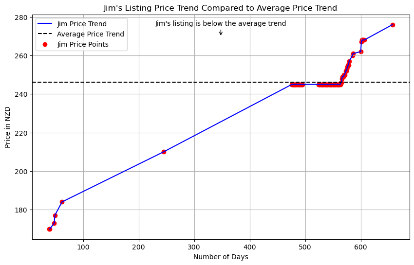

```python
sorted_prices['Price'] = pd.to_numeric(sorted_prices['Price'], errors='coerce')

#Average price trend over the 90 days for all listings
average_price_trend = sorted_prices.groupby('Listing')['Price'].mean().reset_index()

#Average price trend across all listings
average_price_across_listings = average_price_trend['Price'].mean()

#Jim's listing price trend
jim_prices = sorted_prices[sorted_prices['Listing'] == 'Jim Price in NZD']['Price']

#Jim's listing price trend plot
plt.figure(figsize=(10, 6))
plt.plot(jim_prices, label='Jim Price Trend', color='blue')
plt.axhline(y=average_price_across_listings, color='black', linestyle='--', label='Average Price Trend')

#Jim's listing price points
plt.scatter(jim_prices.index, jim_prices, color='red', label='Jim Price Points')

#Annotation to indicate whether Jim's listing is above or below the average trend
if jim_prices.mean() > average_price_across_listings:
    annotation_text = 'Jim\'s listing is above the average trend'
else:
    annotation_text = 'Jim\'s listing is below the average trend'

plt.annotate(annotation_text,
             xy=(0.5, 0.9), xycoords='axes fraction',
             xytext=(0.5, 0.95), textcoords='axes fraction',
             horizontalalignment='center',
             arrowprops=dict(facecolor='black', arrowstyle='->'))

plt.xlabel('Number of Days')
plt.ylabel('Price in NZD')
plt.title('Jim\'s Listing Price Trend Compared to Average Price Trend')
plt.legend()
plt.grid(True)
plt.show()
```

### Second part made by: Ning Jian (23019851)

```python
import numpy as np
import pandas as pd
import seaborn as sns
import matplotlib as mpl
import matplotlib.pyplot as plt
import json
import re

from pylab import rcParams
rcParams['figure.figsize'] = 7, 5
rcParams['font.size'] = 10
rcParams['axes.facecolor'] = 'white'
%matplotlib inline

#Data Acquisition
import requests                 #How Python gets the webpages
from bs4 import BeautifulSoup   #Creates structured, searchable object

import os
from tabulate import tabulate
from datetime import datetime, timedelta
import time

#!pip install --upgrade selenium
from selenium import webdriver #Provides an API for controlling web browsers programmatically.

from selenium import webdriver
from selenium.webdriver.chrome.service import Service
from webdriver_manager.chrome import ChromeDriverManager
from selenium.webdriver.common.by import By
from selenium.common.exceptions import NoSuchElementException

from urllib.parse import urlparse
from urllib.parse import urlparse, parse_qs
import pandas as pd
```

### 1. Web Scraping

```python
#Function to scrape availability and pricing data for a listing
def scrape_listing_pricing(listing_url, guests, num_days):

    #Configure Selenium options
    options = webdriver.ChromeOptions()
    options.add_argument('--headless')  #Run Chrome in headless mode (no GUI)
    options.add_argument('--disable-gpu')  #Disable GPU acceleration
    options.add_argument('--no-sandbox')  #Bypass OS security model
    options.add_argument('--disable-dev-shm-usage')  #Overcome limited resource problems

    #Initialize ChromeDriver
    s=Service(ChromeDriverManager().install())
    driver = webdriver.Chrome(service=s, options=options)
    #driver = webdriver.Chrome(options=options)

    # Open the webpage
    driver.get(listing_url)

    # Get the current URL
    current_url = driver.current_url

    # Parse the URL
    parsed_url = urlparse(current_url)

    # Get the query parameters
    query_params = parse_qs(parsed_url.query)

    # Get the source_impression_id
    source_impression_id = query_params.get('source_impression_id', [None])[0]


    #Create a DataFrame to store the data
    df = pd.DataFrame(columns=['Check-in Date', 'Check-out Date', 'Price in NZD'])

    #Iterate through the next 'num_days' days
    start_date = datetime.now()
    end_date = start_date + timedelta(days=num_days-1)  #Adjusted to avoid checking for prices on the last day
    current_date = start_date

    while current_date <= end_date:
        #Calculate checkin and checkout dates for the overnight stay
        checkin_date = current_date.strftime('%Y-%m-%d')
        checkout_date = (current_date + timedelta(days=2)).strftime('%Y-%m-%d')
        source_impression_id = 'p3_1715742585_kCMjvilSUXWV608%2B'

        #Construct the URL
        url = f"{listing_url}?check_in={checkin_date}&guests=3&adults=3&check_out={checkout_date}&source_impression_id={source_impression_id}"

        print(url)

        #Open the URL in ChromeDriver
        driver.get(url)

        #Wait for dynamic content to load (adjust sleep time as needed)
        time.sleep(1)  # Wait for 5 seconds

        #Parse the page content with BeautifulSoup
        soup = BeautifulSoup(driver.page_source, 'html.parser')

        #Find the span element containing the price
        price_element = soup.find(class_='_1y74zjx')
        house_elements = soup.findAll(class_='l7n4lsf atm_9s_1o8liyq_keqd55 dir dir-ltr')
        # Create a list to collect all numbers
        all_numbers = []
        for element in house_elements:

            data = element.text
            numbers = re.findall(r'\d+', data)
            all_numbers.extend(numbers)


        # Assign the numbers to variables
        Guests = int(all_numbers[0]) if len(all_numbers) > 0 else 'NaN'
        bedrooms = int(all_numbers[1]) if len(all_numbers) > 1 else 'NaN'
        beds = int(all_numbers[2]) if len(all_numbers) > 2 else 'NaN'
        baths = int(all_numbers[3]) if len(all_numbers) > 3 else 'NaN'
        years_hosting = int(all_numbers[4]) if len(all_numbers) > 4 else 'NaN'

        print("Guests:", Guests)
        print("Bedrooms:", bedrooms)
        print("Beds:", beds)
        print("Baths:", baths)
        print("Years hosting:", years_hosting)



    #If price element is found
        if price_element:
            #Extract the text content of the span element
            price_text = price_element.text.strip()

            #Extract only the numerical part of the text (assuming it's the first occurrence of a number)
            price = re.search(r'\d+', price_text).group()
            #Add data to DataFrame
            df = pd.concat([df, pd.DataFrame({'Host':[listing_url],'Check-in Date': [checkin_date], 'Check-out Date': [checkout_date], 'Price in NZD': [price], 'Guest':[Guests], 'bedrooms':[bedrooms], 'beds':[beds],'baths':[baths],'years_hosting':[years_hosting]})],ignore_index=True)
            print(price)

        else:

            price = 'NaN'
            print(f"Price not found for {checkin_date} - {checkout_date}. Price is {price}")
            df = pd.concat([df, pd.DataFrame({'Host':[listing_url],'Check-in Date': [checkin_date], 'Check-out Date': [checkout_date], 'Price in NZD': [price], 'Guest':[Guests], 'bedrooms':[bedrooms], 'beds':[beds],'baths':[baths],'years_hosting':[years_hosting]})], ignore_index=True)


        #Move to the next day
        current_date += timedelta(days=1)

    #Close the ChromeDriver
    #driver.quit()

    return df
```

Test read one Url and scrape data

```python
#Example URL and parameters
listing_url = 'https://www.airbnb.co.nz/rooms/49525122'
guests = 3
num_days = 3 #change to 180 for 6 Months

#Scrape pricing data for the next 180 days
pricing_data = scrape_listing_pricing(listing_url, guests, num_days)

pricing_data
```

```
https://www.airbnb.co.nz/rooms/49525122?check_in=2024-05-28&guests=3&adults=3&check_out=2024-05-30&source_impression_id=p3_1715742585_kCMjvilSUXWV608%2B
Guests: 6
Bedrooms: 2
Beds: 3
Baths: 2
Years hosting: 3
151
https://www.airbnb.co.nz/rooms/49525122?check_in=2024-05-29&guests=3&adults=3&check_out=2024-05-31&source_impression_id=p3_1715742585_kCMjvilSUXWV608%2B
Guests: 6
Bedrooms: 2
Beds: 3
Baths: 2
Years hosting: 3
151
https://www.airbnb.co.nz/rooms/49525122?check_in=2024-05-30&guests=3&adults=3&check_out=2024-06-01&source_impression_id=p3_1715742585_kCMjvilSUXWV608%2B
Guests: 6
Bedrooms: 2
Beds: 3
Baths: 2
Years hosting: 3
154
```

|  | Check-in Date | Check-out Date | Price in NZD | Host | Guest | bedrooms | beds | baths | years_hosting |
| --- | --- | --- | --- | --- | --- | --- | --- | --- | --- |
| 0 | 2024-05-28 | 2024-05-30 | 151 | https://www.airbnb.co.nz/rooms/49525122 | 6.0 | 2.0 | 3.0 | 2.0 | 3.0 |
| 1 | 2024-05-29 | 2024-05-31 | 151 | https://www.airbnb.co.nz/rooms/49525122 | 6.0 | 2.0 | 3.0 | 2.0 | 3.0 |
| 2 | 2024-05-30 | 2024-06-01 | 154 | https://www.airbnb.co.nz/rooms/49525122 | 6.0 | 2.0 | 3.0 | 2.0 | 3.0 |

### 2. Data Import and Data Wrangling

```python
import matplotlib.pyplot as plt
from sklearn.model_selection import train_test_split
from sklearn.linear_model import LinearRegression
from sklearn.metrics import mean_squared_error, r2_score
from sklearn.neighbors import KNeighborsClassifier
from sklearn.preprocessing import StandardScaler
```

```python
# Load the dataset
file_path = 'Competitor Calendar data_Total_5_22.csv'
data = pd.read_csv(file_path)

data.head(100)
```

|  | dates | Beautiful home in Browns Bay (13997779) | Beautiful home in Browns Bay (13997779).1 | Sunny Beach Retreat (18348257) | Sunny Beach Retreat (18348257).1 | Spacious sunny family house with garden (41292977) | Spacious sunny family house with garden (41292977).1 | Entire place - 3 bedrooms - house near the beach (707539528122947177) | Entire place - 3 bedrooms - house near the beach (707539528122947177).1 | Harbour View Guesthouse (858452399916773499) | ... | Westlake House (845700994457894280) | Westlake House (845700994457894280).1 | Westlake House (944002805657919757) | Westlake House (944002805657919757).1 | Waters Edge Paradise (973364951141657574) | Waters Edge Paradise (973364951141657574).1 | Three-Bedroom Haven in Greenhithe (1103151815877213297) | Three-Bedroom Haven in Greenhithe (1103151815877213297).1 | Tranquil Lockwood Retreat (1116155057773801595) | Tranquil Lockwood Retreat (1116155057773801595).1 |
| --- | --- | --- | --- | --- | --- | --- | --- | --- | --- | --- | --- | --- | --- | --- | --- | --- | --- | --- | --- | --- | --- |
| 0 | NaN | prices | available | prices | available | prices | available | prices | available | prices | ... | prices | available | prices | available | prices | available | prices | available | prices | available |
| 1 | 22/05/2024 | 151 | 1 | 177 | 1 | 289 | 0 | 130 | 0 | 241 | ... | 380 | 1 | 703 | 1 | 203 | 0 | 566 | 1 | 398 | 0 |
| 2 | 23/05/2024 | 151 | 1 | 246 | 0 | 289 | 0 | 130 | 0 | 241 | ... | 382 | 1 | 703 | 1 | 203 | 0 | 566 | 1 | 398 | 0 |
| 3 | 24/05/2024 | 151 | 1 | 290 | 0 | 289 | 0 | 130 | 0 | 241 | ... | 385 | 1 | 703 | 1 | 203 | 0 | 628 | 1 | 398 | 0 |
| 4 | 25/05/2024 | 151 | 1 | 290 | 0 | 289 | 0 | 130 | 0 | 241 | ... | 385 | 1 | 703 | 1 | 203 | 0 | 608 | 0 | 398 | 0 |
| ... | ... | ... | ... | ... | ... | ... | ... | ... | ... | ... | ... | ... | ... | ... | ... | ... | ... | ... | ... | ... | ... |
| 95 | 24/08/2024 | 151 | 1 | 287 | 0 | 290 | 1 | 171 | 1 | 241 | ... | 385 | 1 | 385 | 1 | 208 | 1 | 628 | 1 | 407 | 1 |
| 96 | 25/08/2024 | 151 | 1 | 251 | 0 | 290 | 1 | 174 | 1 | 241 | ... | 385 | 1 | 385 | 1 | 208 | 1 | 566 | 1 | 407 | 1 |
| 97 | 26/08/2024 | 151 | 1 | 251 | 0 | 290 | 1 | 141 | 1 | 241 | ... | 380 | 1 | 385 | 1 | 208 | 1 | 566 | 1 | 407 | 1 |
| 98 | 27/08/2024 | 151 | 1 | 251 | 0 | 290 | 1 | 123 | 1 | 241 | ... | 380 | 1 | 385 | 1 | 208 | 1 | 566 | 1 | 407 | 1 |
| 99 | 28/08/2024 | 151 | 1 | 251 | 0 | 290 | 1 | 131 | 1 | 241 | ... | 380 | 1 | 385 | 1 | 208 | 1 | 566 | 1 | 407 | 1 |

100 rows × 221 columns

```python
# Get the values of the 0th row
row_0_values = data.iloc[0]

# Find the columns where the 0th row equals 'prices'
prices_columns = row_0_values[row_0_values == 'prices'].index

# Select the 'prices' columns from the DataFrame
prices_data = data[prices_columns]

# Add the 'dates' column to the DataFrame
prices_data = pd.concat([data['dates'], prices_data], axis=1)

# Display the first few rows of the DataFrame
prices_data.head()
```

|  | dates | Beautiful home in Browns Bay (13997779) | Sunny Beach Retreat (18348257) | Spacious sunny family house with garden (41292977) | Entire place - 3 bedrooms - house near the beach (707539528122947177) | Harbour View Guesthouse (858452399916773499) | Family Beach Getaway (885571378705449047) | Contemporary Browns Bay Haven with Fabulous Patio (974030728064591489) | Mairangi Bay Bliss (979376514129893302) | Villa Wisteria - Beautiful home/Private Pool (1048534481893002772) | ... | Spectacular views on the North Shore ! (15330183) | Boutique Beach Beauty (22484105) | Stunning Treehouse Oasis close to CBD & Beach (23147662) | Milford Getaway 3 rooms (820473814265259551) | Newly renovated Spacious 4BR home views to LongBay (827076618263063247) | Westlake House (845700994457894280) | Westlake House (944002805657919757) | Waters Edge Paradise (973364951141657574) | Three-Bedroom Haven in Greenhithe (1103151815877213297) | Tranquil Lockwood Retreat (1116155057773801595) |
| --- | --- | --- | --- | --- | --- | --- | --- | --- | --- | --- | --- | --- | --- | --- | --- | --- | --- | --- | --- | --- | --- |
| 0 | NaN | prices | prices | prices | prices | prices | prices | prices | prices | prices | ... | prices | prices | prices | prices | prices | prices | prices | prices | prices | prices |
| 1 | 22/05/2024 | 151 | 177 | 289 | 130 | 241 | 482 | 249 | 282 | 275 | ... | 521 | 289 | 275 | 334 | 325 | 380 | 703 | 203 | 566 | 398 |
| 2 | 23/05/2024 | 151 | 246 | 289 | 130 | 241 | 482 | 223 | 282 | 275 | ... | 521 | 289 | 275 | 334 | 325 | 382 | 703 | 203 | 566 | 398 |
| 3 | 24/05/2024 | 151 | 290 | 289 | 130 | 241 | 482 | 223 | 282 | 272 | ... | 521 | 289 | 290 | 334 | 325 | 385 | 703 | 203 | 628 | 398 |
| 4 | 25/05/2024 | 151 | 290 | 289 | 130 | 241 | 482 | 223 | 282 | 272 | ... | 521 | 289 | 290 | 334 | 325 | 385 | 703 | 203 | 608 | 398 |

5 rows × 111 columns

```python
# Save the first column name
first_column_name = prices_data.columns[0]

# Define a regular expression pattern to match numbers within parentheses
pattern = r'\((\d+)\)'

# Apply the pattern to each column name
new_column_names = prices_data.columns.str.extract(pattern, expand=False)

# Create a dictionary mapping old column names to new column names
column_name_mapping = dict(zip(prices_data.columns, new_column_names))

# Rename the columns of the DataFrame
prices_data.rename(columns=column_name_mapping, inplace=True)

# Restore the first column name
prices_data.rename(columns={prices_data.columns[0]: first_column_name}, inplace=True)

prices_data.head(100)
```

|  | dates | 13997779 | 18348257 | 41292977 | 707539528122947177 | 858452399916773499 | 885571378705449047 | 974030728064591489 | 979376514129893302 | 1048534481893002772 | ... | 15330183 | 22484105 | 23147662 | 820473814265259551 | 827076618263063247 | 845700994457894280 | 944002805657919757 | 973364951141657574 | 1103151815877213297 | 1116155057773801595 |
| --- | --- | --- | --- | --- | --- | --- | --- | --- | --- | --- | --- | --- | --- | --- | --- | --- | --- | --- | --- | --- | --- |
| 0 | NaN | prices | prices | prices | prices | prices | prices | prices | prices | prices | ... | prices | prices | prices | prices | prices | prices | prices | prices | prices | prices |
| 1 | 22/05/2024 | 151 | 177 | 289 | 130 | 241 | 482 | 249 | 282 | 275 | ... | 521 | 289 | 275 | 334 | 325 | 380 | 703 | 203 | 566 | 398 |
| 2 | 23/05/2024 | 151 | 246 | 289 | 130 | 241 | 482 | 223 | 282 | 275 | ... | 521 | 289 | 275 | 334 | 325 | 382 | 703 | 203 | 566 | 398 |
| 3 | 24/05/2024 | 151 | 290 | 289 | 130 | 241 | 482 | 223 | 282 | 272 | ... | 521 | 289 | 290 | 334 | 325 | 385 | 703 | 203 | 628 | 398 |
| 4 | 25/05/2024 | 151 | 290 | 289 | 130 | 241 | 482 | 223 | 282 | 272 | ... | 521 | 289 | 290 | 334 | 325 | 385 | 703 | 203 | 608 | 398 |
| ... | ... | ... | ... | ... | ... | ... | ... | ... | ... | ... | ... | ... | ... | ... | ... | ... | ... | ... | ... | ... | ... |
| 95 | 24/08/2024 | 151 | 287 | 290 | 171 | 241 | 482 | 856 | 282 | 275 | ... | 523 | 302 | 290 | 334 | 295 | 385 | 385 | 208 | 628 | 407 |
| 96 | 25/08/2024 | 151 | 251 | 290 | 174 | 241 | 482 | 613 | 282 | 275 | ... | 523 | 302 | 275 | 334 | 295 | 385 | 385 | 208 | 566 | 407 |
| 97 | 26/08/2024 | 151 | 251 | 290 | 141 | 241 | 482 | 608 | 282 | 275 | ... | 523 | 302 | 275 | 334 | 295 | 380 | 385 | 208 | 566 | 407 |
| 98 | 27/08/2024 | 151 | 251 | 290 | 123 | 241 | 482 | 589 | 282 | 275 | ... | 523 | 302 | 275 | 334 | 295 | 380 | 385 | 208 | 566 | 407 |
| 99 | 28/08/2024 | 151 | 251 | 290 | 131 | 241 | 482 | 594 | 282 | 275 | ... | 523 | 302 | 275 | 334 | 295 | 380 | 385 | 208 | 566 | 407 |

100 rows × 111 columns

```python
# Drop the first row
prices_data = prices_data.drop(prices_data.index[0])

# Drop duplicate columns
prices_data = prices_data.loc[:,~prices_data.columns.duplicated()]

# Drop rows where 'dates' is NaN
prices_data = prices_data.dropna(subset=['dates'])


prices_data['dates'] = pd.to_datetime(prices_data['dates'])



prices_data.iloc[:, 1:] = prices_data.iloc[:, 1:].apply(pd.to_numeric, errors='coerce')

# Collect the column names to drop
columns_to_drop = [column for column in prices_data.columns[1:] if (prices_data[column] >= 1000).any()]

# Drop the columns
prices_data.drop(columns_to_drop, axis=1, inplace=True)


# Collect the column names to drop
columns_to_drop = [column for column in prices_data.columns[1:] if (prices_data[column] >= 1000).any()]

# Drop the columns
prices_data.drop(columns_to_drop, axis=1, inplace=True)

# Display the first few rows of the DataFrame
prices_data.head(100)
```

|  | dates | 13997779 | 18348257 | 41292977 | 707539528122947177 | 858452399916773499 | 885571378705449047 | 974030728064591489 | 979376514129893302 | 1048534481893002772 | ... | 996601818908446283 | 15330183 | 22484105 | 23147662 | 820473814265259551 | 827076618263063247 | 845700994457894280 | 944002805657919757 | 973364951141657574 | 1116155057773801595 |
| --- | --- | --- | --- | --- | --- | --- | --- | --- | --- | --- | --- | --- | --- | --- | --- | --- | --- | --- | --- | --- | --- |
| 1 | 2024-05-22 | 151 | 177 | 289 | 130 | 241.0 | 482.0 | 249 | 282.0 | 275 | ... | 334 | 521 | 289 | 275.0 | 334.0 | 325 | 380.0 | 703 | 203 | 398 |
| 2 | 2024-05-23 | 151 | 246 | 289 | 130 | 241.0 | 482.0 | 223 | 282.0 | 275 | ... | 334 | 521 | 289 | 275.0 | 334.0 | 325 | 382.0 | 703 | 203 | 398 |
| 3 | 2024-05-24 | 151 | 290 | 289 | 130 | 241.0 | 482.0 | 223 | 282.0 | 272 | ... | 334 | 521 | 289 | 290.0 | 334.0 | 325 | 385.0 | 703 | 203 | 398 |
| 4 | 2024-05-25 | 151 | 290 | 289 | 130 | 241.0 | 482.0 | 223 | 282.0 | 272 | ... | 334 | 521 | 289 | 290.0 | 334.0 | 325 | 385.0 | 703 | 203 | 398 |
| 5 | 2024-05-26 | 151 | 246 | 289 | 130 | 241.0 | 482.0 | 223 | 282.0 | 275 | ... | 334 | 521 | 289 | 275.0 | 334.0 | 325 | 385.0 | 703 | 203 | 398 |
| ... | ... | ... | ... | ... | ... | ... | ... | ... | ... | ... | ... | ... | ... | ... | ... | ... | ... | ... | ... | ... | ... |
| 96 | 2024-08-25 | 151 | 251 | 290 | 174 | 241.0 | 482.0 | 613 | 282.0 | 275 | ... | 334 | 523 | 302 | 275.0 | 334.0 | 295 | 385.0 | 385 | 208 | 407 |
| 97 | 2024-08-26 | 151 | 251 | 290 | 141 | 241.0 | 482.0 | 608 | 282.0 | 275 | ... | 334 | 523 | 302 | 275.0 | 334.0 | 295 | 380.0 | 385 | 208 | 407 |
| 98 | 2024-08-27 | 151 | 251 | 290 | 123 | 241.0 | 482.0 | 589 | 282.0 | 275 | ... | 334 | 523 | 302 | 275.0 | 334.0 | 295 | 380.0 | 385 | 208 | 407 |
| 99 | 2024-08-28 | 151 | 251 | 290 | 131 | 241.0 | 482.0 | 594 | 282.0 | 275 | ... | 334 | 523 | 302 | 275.0 | 334.0 | 295 | 380.0 | 385 | 208 | 407 |
| 100 | 2024-08-29 | 151 | 251 | 290 | 121 | 241.0 | 482.0 | 626 | 282.0 | 275 | ... | 334 | 523 | 302 | 275.0 | 334.0 | 295 | 382.0 | 385 | 208 | 407 |

100 rows × 100 columns

```python
# Replace the invalid values with the column mean
for column in prices_data.columns[1:]:
    prices_data[column] = prices_data[column].replace([-1633, -1638], np.nan)
    column_mean = prices_data[column].mean()
    prices_data[column] = prices_data[column].fillna(column_mean)
```

```python
# Drop the rows after November 3rd 2024
prices_data = prices_data[prices_data['dates'] <= '2024-11-02']
```

```python
# prices_data.to_csv('prices_data.csv', index=False)
```

### 3 Exploratory Data Analysis (EDA)

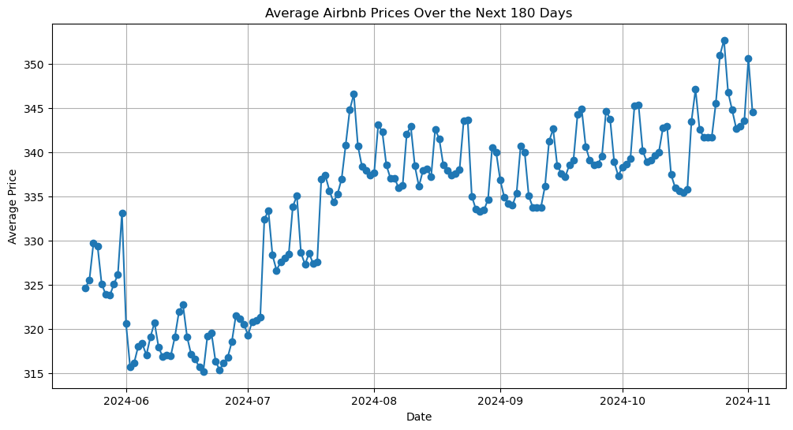

```python
import matplotlib.pyplot as plt
import seaborn as sns


# Parse dates
prices_data['dates'] = pd.to_datetime(prices_data['dates'])

# Check for missing values
missing_values = prices_data.isnull().sum()

# Calculate the average price across all properties for each day
prices_data['average_price'] = prices_data.mean(axis=1, numeric_only=True)

# Plot average price trend
plt.figure(figsize=(12, 6))
plt.plot(prices_data['dates'], prices_data['average_price'], marker='o', linestyle='-')
plt.title('Average Airbnb Prices Over the Next 180 Days')
plt.xlabel('Date')
plt.ylabel('Average Price')
plt.grid(True)
plt.show()
```

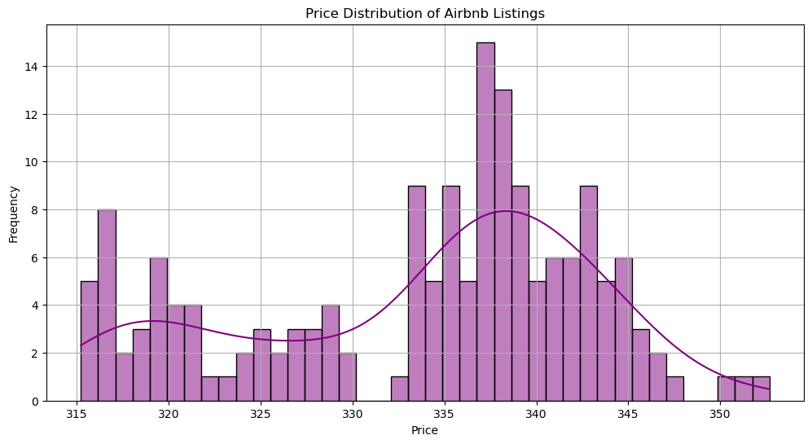

```python
# Price Distribution Of Airbnb Listings
# Plot the distribution of prices
plt.figure(figsize=(12, 6))
sns.histplot(prices_data['average_price'], bins=40, kde=True, color='purple')
plt.title('Price Distribution of Airbnb Listings')
plt.xlabel('Price')
plt.ylabel('Frequency')
plt.grid(True)
plt.show()
```

### 4 Regression Analysis Results

```python
from sklearn.model_selection import train_test_split
from sklearn.linear_model import LinearRegression
from sklearn.metrics import mean_absolute_error, mean_squared_error, r2_score
import numpy as np

# Feature and target variable
X = prices_data.drop(columns=['dates', 'average_price'])
y = prices_data['average_price']

# Splitting the data into training and testing sets
X_train, X_test, y_train, y_test = train_test_split(X, y, test_size=0.2, random_state=42)

# Training the linear regression model
linear_regressor = LinearRegression()
linear_regressor.fit(X_train, y_train)

# Predicting the prices
y_pred = linear_regressor.predict(X_test)

# Evaluating the model
mae = mean_absolute_error(y_test, y_pred)
mse = mean_squared_error(y_test, y_pred)
rmse = np.sqrt(mse)
r2 = r2_score(y_test, y_pred)

mae, rmse, r2
```

```
(8.612639221334548e-14, 1.1874202934156835e-13, 1.0)
```

Regression Analysis Results The linear regression model's performance metrics are as follows:

R-Squared (R²): 1.0

These results show that regression model fits the data almost perfectly:

MAE and RMSE are very close to zero: this indicates that the error between the predicted value of the model and the actual value is almost zero. The r-squared is equal to 1.0: this means that the model accounts for all of the variation in the data and is a perfect fit.

### 5 K-Nearest Neighbors (KNN) Analysis Results

```python
from sklearn.neighbors import KNeighborsRegressor

# Training the KNN model
knn_regressor = KNeighborsRegressor(n_neighbors=5)
knn_regressor.fit(X_train, y_train)

# Predicting the prices
y_knn_pred = knn_regressor.predict(X_test)

# Evaluating the model
knn_mae = mean_absolute_error(y_test, y_knn_pred)
knn_mse = mean_squared_error(y_test, y_knn_pred)
knn_rmse = np.sqrt(knn_mse)
knn_r2 = r2_score(y_test, y_knn_pred)

knn_mae, knn_rmse, knn_r2
```

```
(1.4869198852119618, 2.066033657691992, 0.9586689514647733)
```

### 6 Prediction and Optimization

To forecast future bookings and determine the optimal pricing strategy, we'll consider the trends and patterns identified, along with the results from our regression and KNN models.

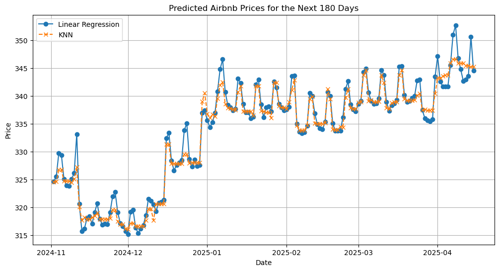

```python
# Predict future prices using the linear regression model
future_dates = pd.date_range(start=prices_data['dates'].max(), periods=165, freq='D')
future_data = pd.DataFrame(future_dates, columns=['dates'])
future_data_X = X.iloc[:165, :]  # Using the first 180 rows as a placeholder

future_data['linear_regression_price'] = linear_regressor.predict(future_data_X)
future_data['knn_price'] = knn_regressor.predict(future_data_X)

# Plotting the future prices
plt.figure(figsize=(12, 6))
plt.plot(future_data['dates'], future_data['linear_regression_price'], marker='o', linestyle='-', label='Linear Regression')
plt.plot(future_data['dates'], future_data['knn_price'], marker='x', linestyle='--', label='KNN')
plt.title('Predicted Airbnb Prices for the Next 180 Days')
plt.xlabel('Date')
plt.ylabel('Price')
plt.legend()
plt.grid(True)
plt.show()
```

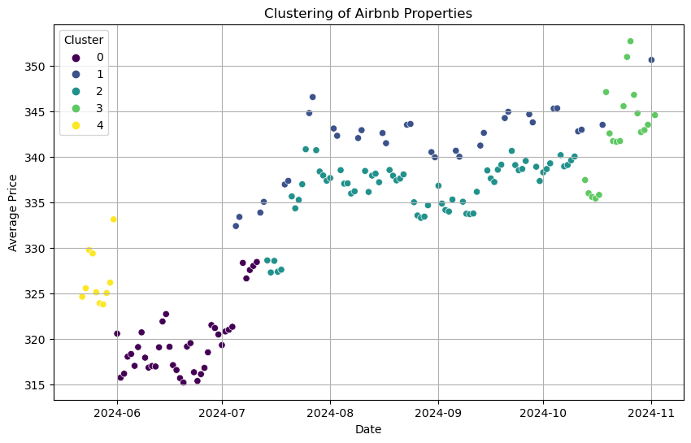

```python
from sklearn.cluster import KMeans
from sklearn.preprocessing import StandardScaler

# Standardize the data
scaler = StandardScaler()
X_scaled = scaler.fit_transform(X)

# Apply k-means clustering
kmeans = KMeans(n_clusters=5, random_state=42)
prices_data['cluster'] = kmeans.fit_predict(X_scaled)

# Plot clusters
plt.figure(figsize=(10, 6))
sns.scatterplot(x=prices_data['dates'], y=prices_data['average_price'], hue=prices_data['cluster'], palette='viridis')
plt.title('Clustering of Airbnb Properties')
plt.xlabel('Date')
plt.ylabel('Average Price')
plt.grid(True)
plt.legend(title='Cluster')
plt.show()
```

### Third part made by: Jesse Shen (23020703)

```python
import numpy as np
import pandas as pd
import seaborn as sns
import matplotlib as mpl
import matplotlib.pyplot as plt
import json
import re

from sklearn import preprocessing, neighbors

from pylab import rcParams
rcParams['figure.figsize'] = 7, 5
rcParams['font.size'] = 10
rcParams['axes.facecolor'] = 'white'
%matplotlib inline

#Data Acquisition
import requests                 #How Python gets the webpages
from bs4 import BeautifulSoup   #Creates structured, searchable object

import os
from pathlib import Path
from tabulate import tabulate
from datetime import datetime, timedelta
import time

# !pip install --upgrade selenium
from selenium import webdriver #Provides an API for controlling web browsers programmatically.
```

```python
# Configure Selenium options
options = webdriver.ChromeOptions()
options.add_argument('--headless')  # Run Chrome in headless mode (no GUI)
options.add_argument('--disable-gpu')  # Disable GPU acceleration
options.add_argument('--no-sandbox')  # Bypass OS security model
options.add_argument('--disable-dev-shm-usage')  # Overcome limited resource problems

# Declare a global web driver variable
driver = None

# Store the current date time into a global variable
start_date = datetime.now()

# If the today's date is odd, make start_date tomorrow's date
if (int(start_date.strftime("%d")) % 2):
    start_date += timedelta(days=1)

# Set the directory path to read or write .csv files in
dir_path = "datasets"

# If the directory doesn't exist, create one
if not os.path.exists(dir_path):
    os.makedirs(dir_path)
```

```python
# Function to open the global web driver
def set_up_driver():
    global driver
    # driver = webdriver.Chrome(options=options) # Run Chrome in headless mode (no GUI)
    driver = webdriver.Chrome()

# Function to make an http request to the url provided using the global web driver and return the soup object
def http_request(url, seconds=1):
    driver.get(url)

    # Wait for dynamic content to load (adjust sleep time as needed)
    time.sleep(seconds)

    return BeautifulSoup(driver.page_source, "html.parser")

# Function to close the global web driver
def close_driver():
    driver.quit()
```

```python
# Function for scraping rooms' info from the web page to the target url, and return a dataframe of the rooms's info
def get_rooms(url):
    # Set the path to a .csv file to read or write the dataframe info
    file_path = f"{dir_path}/rooms.csv"

    # If the .csv file that stores the rooms' dataframe already exists, read that into a dataframe and return it
    if Path(file_path).is_file():
        return pd.read_csv(file_path, index_col=0)

    set_up_driver()

    # Webscrape from the url and find the <a> elements that have room's url as its href attribute
    elements = http_request(url, 3).findAll("a", "l1ovpqvx atm_1he2i46_1k8pnbi_10saat9 atm_yxpdqi_1pv6nv4_10saat9 atm_1a0hdzc_w1h1e8_10saat9 atm_ywwsz3_1afjdsa_10saat9 atm_1lnvhrj_zhgkwc_10saat9 atm_8i46q5_63ecz1_10saat9 bn2bl2p atm_5j_223wjw atm_9s_1ulexfb atm_e2_1osqo2v atm_fq_idpfg4 atm_mk_stnw88 atm_tk_idpfg4 atm_vy_1osqo2v atm_26_1j28jx2 atm_3f_glywfm atm_kd_glywfm atm_3f_glywfm_jo46a5 atm_l8_idpfg4_jo46a5 atm_gi_idpfg4_jo46a5 atm_3f_glywfm_1icshfk atm_kd_glywfm_19774hq atm_uc_aaiy6o_1w3cfyq_oggzyc atm_70_1b8lkes_1w3cfyq_oggzyc atm_uc_glywfm_1w3cfyq_pynvjw atm_uc_aaiy6o_pfnrn2_ivgyl9 atm_70_1b8lkes_pfnrn2_ivgyl9 atm_uc_glywfm_pfnrn2_61fwbc dir dir-ltr")

    # Map each element in the found elements to room_num by extracting the room_num in its href attribute
    room_nums = [int(re.search(r'(?<=^/rooms/)\d+(?=\?)', element.get("href")).group()) for element in elements]

    # Initialize a list for storing rooms' info
    arr = []

    # Loop through the list of room_nums
    for room_num in room_nums:
        href = f"https://www.airbnb.co.nz/rooms/{room_num}"

        # Get the <li> elements containing information of the target room
        elems = http_request(href).findAll("li", "l7n4lsf atm_9s_1o8liyq_keqd55 dir dir-ltr")

        # If no <li> found, just skip this room
        if len(elems) == 0:
            continue

        # Initialize a dict for storing room's info with it's id set to room_num
        info = {"id": room_num}

        # Extract the guest's number from the first element
        guests = re.search(r"\d+(?= guest)", elems[0].text)
        if guests != None:
            info["guests"] = int(guests.group())
        else:
            continue

        # Extract the bedrooms' number from the second element
        bedrooms = re.search(r"\d+(?= bedroom)", elems[1].text)
        if bedrooms != None:
            info["bedrooms"] = int(bedrooms.group())
        else:
            continue

        # Extract the beds' number from the third element
        beds = re.search(r"\d+(?= bed)", elems[2].text)
        if beds != None:
            info["beds"] = int(beds.group())
        else:
            continue

        # Extract the baths' number from the fourth element
        baths = re.search(r"\d+(?= bath)", elems[3].text)
        if baths != None:
            info["baths"] = int(baths.group())
        else:
            continue

        info["href"] = href

        # If all the four kinds of info are awailable, take that room info into account
        arr.append(info)

    close_driver()

    # Create a dataframe from the list of rooms' info
    df = pd.DataFrame(arr)

    df.set_index("id", inplace=True)

    # Write the dataframe into the .csv file for next use
    # So for next time call of this function, we can directly create the dataframe from the file if the file eixts without time consuming webscraping
    df.to_csv(file_path)

    return df
```

**Houses information in Albndy**

```python
# We analyse houses in Albany area
albany_url = "https://www.airbnb.co.nz/s/Albany--Auckland--New-Zealand/homes"
rooms_df = get_rooms(albany_url)
rooms_df.head()
```

| id | guests | bedrooms | beds | baths | href |
| --- | --- | --- | --- | --- | --- |
| 18023402 | 5 | 3 | 3 | 1 | https://www.airbnb.co.nz/rooms/18023402 |
| 36149227 | 3 | 2 | 2 | 5 | https://www.airbnb.co.nz/rooms/36149227 |
| 566211381824024109 | 4 | 3 | 4 | 2 | https://www.airbnb.co.nz/rooms/566211381824024109 |
| 635947170438929163 | 5 | 3 | 3 | 2 | https://www.airbnb.co.nz/rooms/635947170438929163 |
| 1068446442449836873 | 6 | 3 | 3 | 5 | https://www.airbnb.co.nz/rooms/1068446442449836873 |

```python
# Function that take the id of a room and the number of days for sraping the pricing data and return a dataframe
def get_prices(id, num_days):
    # Set the path to the .csv file for storing the dataframe
    file_path = f"{dir_path}/{id}.csv"

    # If the .csv file already exists, read that into a dataframe and return it
    if Path(file_path).is_file():
        return pd.read_csv(file_path, index_col='date', parse_dates=True)

    # Delere start_date as the global variable start_date
    global start_date

    # Initialize a list for storing room's pricing data
    arr = []

    set_up_driver()

    # Iterate on a range from 0 to the number of days
    for i in range(0, num_days):
        # Set the checkin_date based on the start_date and i day's later
        checkin_date = (start_date + timedelta(days=i)).strftime('%Y-%m-%d')

        # Set the checkout_date 2 days after the checkin_date
        checkout_date = (start_date + timedelta(days=i+1)).strftime('%Y-%m-%d')

        # Compose the url for sraping the pricing data for the room, checkin_date and checkout_date
        url = f"https://www.airbnb.co.nz/rooms/{id}?check_in={checkin_date}&check_out={checkout_date}"

        # Store the result into a soup object
        soup = http_request(url)

        # Initialize a dict for storing the pricing data
        info = {"date": checkin_date}

        # If there's a <button aria-describedby="bookItTripDetailsError">...<button> element,
        # this means it's unailable for booking and the price can't be find
        # We simply check if that element exists and store the result as a boolean value
        isAvailable = soup.find("button", attrs={"aria-describedby": "bookItTripDetailsError"}) == None

        # Check if isAvailable is set to True and the element holding the price can be find
        # If it's truthy, extract the price value and store it in info["price"],
        # else set the value as NaN
        if isAvailable and ((price_element := soup.find('span', class_='_1y74zjx')) != None):
            info["price"] = float(re.search(r'\d+', price_element.text).group())
        else:
            info["price"] = -1632.0

        # Take the pricing data in to account
        arr.append(info)

    close_driver()

    # Create a datafrom from list for storing the room's pricing data
    df = pd.DataFrame(arr)

    df['date'] = pd.to_datetime(df['date'], format='%Y-%m-%d')
    df.set_index('date', inplace=True)

    # Write the dataframe into the .csv file for next use
    # So for next time call of this function, we can directly create the dataframe from the file if the file eixts without time consuming webscraping
    df.to_csv(file_path)

    return df
```

**Daily price of a house in Albany**

```python
num_days = 180
room0 = get_prices(rooms_df.index[0], 180)
room0.head()
```

| date | price |
| --- | --- |
| 2024-05-18 | 529.0 |
| 2024-05-19 | 529.0 |
| 2024-05-20 | 529.0 |
| 2024-05-21 | 529.0 |
| 2024-05-22 | 529.0 |

```python
# Function that takes a list-like object of room ids and the number of days
# For each room id, create a dataframe of pricing data and store that dataframe in the dict to return with the key as the room id
def get_room_df_dict(ids, num_days):
    room_df_dict = {}
    start_time = datetime.now()
    for id in ids:
        room_df_dict[id] = get_prices(id, num_days)
    finish_time = datetime.now()
    print(f"It takes {finish_time - start_time} to fetch data")
    return room_df_dict
```

```python
num_days = 180
room_df_dict = get_room_df_dict(rooms_df.index, num_days)
```

```
It takes 0:00:00.101548 to fetch data
```

```python
# Function given paticular features and a paticular date to predict the price
def predict(features, date, k=5):
    # For storing features taken into account
    columns_to_take = []

    # For storing data for knn to model on
    X = []
    y = []

    # For storing features data to predict at
    x = []

    # Figure out features to take into account and features data predict at
    if "guests" in features:
        columns_to_take.append("guests")
        x.append(features["guests"])
    if "bedrooms" in features:
        columns_to_take.append("bedrooms")
        x.append(features["bedrooms"])
    if "beds" in features:
        columns_to_take.append("beds")
        x.append(features["beds"])
    if "baths" in features:
        columns_to_take.append("baths")
        x.append(features["baths"])

    # Construct data for knn to model on
    for id in rooms_df.index:
        room_df = room_df_dict[id]
        price = room_df.loc[date]["price"]
        if price > 0:
            X.append(rooms_df.loc[id][columns_to_take].to_list())
            y.append([price])

    # Discards 10th outliers to the min, and 10th to the max for prices
    for count in range(0, round(len(rooms_df) / 10)):
        min_price = y[0][0]
        min_index = 0

        for i, price_list in enumerate(y):
            price = price_list[0]
            if price < min_price:
                min_price = price
                min_index = i

        del X[min_index]
        del y[min_index]

        max_price = y[0][0]
        max_index = 0

        for i, price_list in enumerate(y):
            price = price_list[0]
            if price > max_price:
                max_price = price
                max_index = i

        del X[max_index]
        del y[max_index]

    # Normalize the data to model on
    X = preprocessing.MinMaxScaler().fit_transform(X)

    if k > len(X):
        k = len(X)

    knn = neighbors.KNeighborsRegressor(k, weights="distance")

    return round(knn.fit(X, y).predict([x])[0][0])
```

```python
price = predict({"guests": 2, "bedrooms": 1, "beds": 2}, "2024-07-01", k=5)
print("$%d" % price)
```

```
$286
```

```python
# Function to predict the price for each day for a given feature
def trands(dimensions, k=5):
    arr = []
    for date in room0.index:
        arr.append({"date": date, "price": predict(dimensions, date, k)})
    df = pd.DataFrame(arr)
    df.set_index("date", inplace=True)
    return df
```

**Predict the daily price of a house that accepts 2 guests with 2 beds in Albany**

```python
df1 = trands({"guests": 2, "beds": 2})
df1.head()
```

| date | price |
| --- | --- |
| 2024-05-18 | 257 |
| 2024-05-19 | 233 |
| 2024-05-20 | 231 |
| 2024-05-21 | 250 |
| 2024-05-22 | 250 |

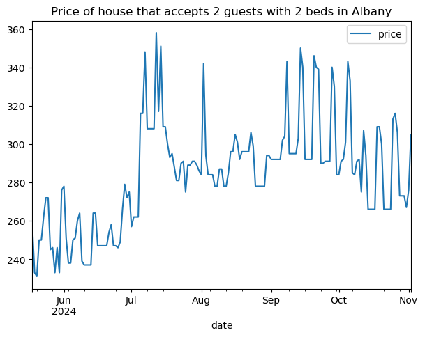

```python
df1.plot()
plt.title("Price of house that accepts 2 guests with 2 beds in Albany")
```

```python
df2 = trands({"guests": 4, "bedrooms": 2})
df2.head()
```

| date | price |
| --- | --- |
| 2024-05-18 | 324 |
| 2024-05-19 | 302 |
| 2024-05-20 | 300 |
| 2024-05-21 | 304 |
| 2024-05-22 | 304 |

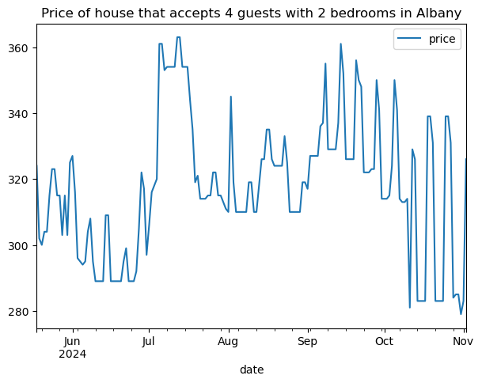

```python
df2.plot()
plt.title("Price of house that accepts 4 guests with 2 bedrooms in Albany")
```

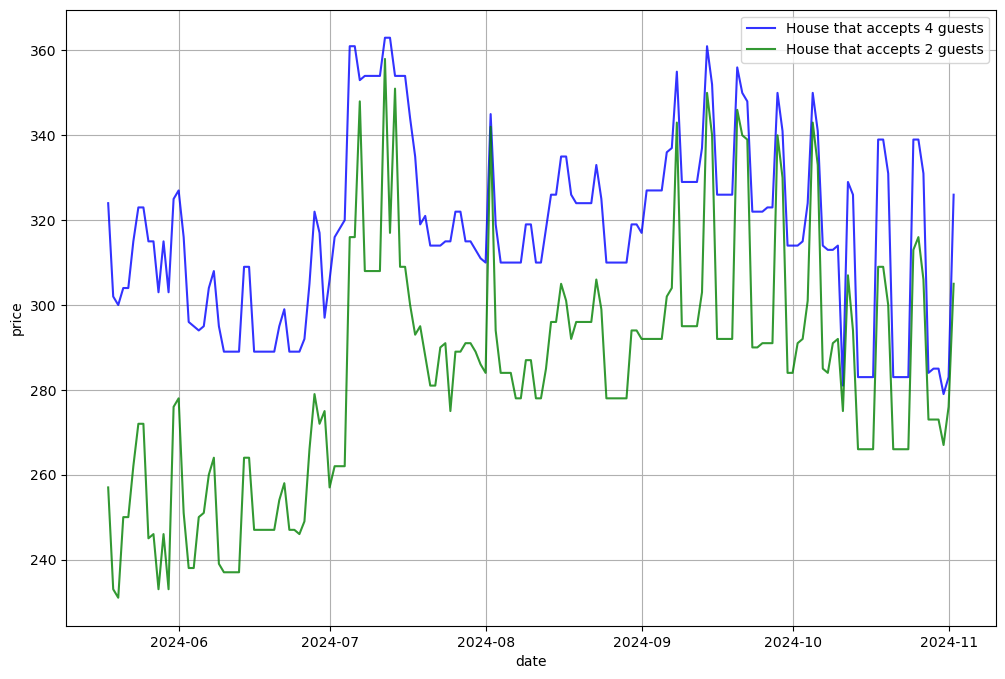

```python
fig, ax = plt.subplots()
fig.set_size_inches(12,8)

ax.plot(df2.index, df2["price"],
            color='b', label='House that accepts 4 guests', alpha=0.8)
ax.plot(df1.index, df1["price"],
            color='g', label='House that accepts 2 guests', alpha=0.8)

ax.set_xlabel('date')
ax.set_ylabel('price')
ax.legend()
ax.grid()
```